# Tankstellen und Kraftstoffpreise 2015

Christopher Dahl

2020-05-23

## Hintergrund

Seit Juni 2014 melden Tankstellen in Deutschland ihre aktuellen Kraftstoffpreise an die Markttransparenzstelle für Kraftstoffe (MTS-K), eine Abteilung des Bundeskartellamtes. Die rechtliche Verpflichtung zur Meldung der Preisinformationen bietet eine seltene Möglichkeit die Entwicklung von Preisen zeitnah flächendeckend zu analysieren. Datenquelle für die Kraftstoffpreise und Tankstellen Informationen ist Tankerkönig.

```r
  # packages
  library(tidyverse)
  library(ggthemes)
  library(gridExtra)
  library(tmap)
  library(leaflet)
  library(leaflet.extras)
  library(rgdal)
  library(DBI)
  library(odbc)

  # themes
  source(file = "code/functions/theme_base_FUN.R", echo = F, encoding = "UTF-8")

  # plot elements
  colors = c("#FF8F00", "#5A8F29", "#3C7DC4", "#2B2B2B")

  # DB connection
  dbcon <- dbConnect(odbc(), "fuelprice", timeout = 10, encoding = "windows-1252", bigint = "integer")
```

# Tankstellen

Für die Übersicht der in Deutschland aktiven Tankstellen, wurden die Daten sämtlicher Tankstellen ausgewertet, welche im Beobachtungszeitraum (01.01. bis 31.12.) mindestens eine Preisinformation übermittelt haben.

## nach Bundesländern

Die räumliche Zuordnung der Tankstellen erfolgt auf Basis der im Datensatz enthalten Angaben zu Längen- und Breitengrad einzelner Tankstellen.

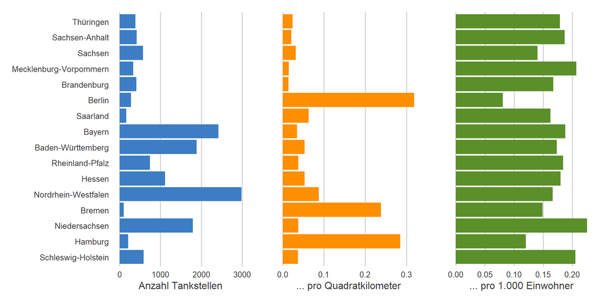

```r
  # query active stations in year
  year <- 2015
  query_stations_year <- paste0("
                    SELECT
                      distinct(stid)
                    FROM
                      price
                    WHERE
                      time BETWEEN '", year,"-01-01 00:00:01'
                           AND '", year,"-12-31 23:59:59'
                    GROUP BY
                      stid;")

  act_stations <- dbGetQuery(dbcon, query_stations_year) %>%
    as_tibble()

  act_stations_string <- paste(act_stations$stid, collapse = ",")

  # Query stations data
  query_states <- paste0("
                    SELECT
                      stations.bl_kz,
                      stations.bl_name,
                      count,
                      area.area_bl,
                      pop.pop_bl,
                      round(count/area.area_bl,4) AS a_dens,
                      round(count*1000/(pop.pop_bl),4) AS p_dens
                    FROM
                      (SELECT
                          bl_kz,
                          bl_name,
                          count(*) AS count
                       FROM
                          stations
                       WHERE
                          bl_kz IS NOT NULL
                       AND
                          uuid = ANY('{",act_stations_string ,"}')
                       GROUP BY bl_kz, bl_name) stations
                    LEFT JOIN
                      (SELECT
                          bl_kz,
                          area_bl
                       FROM
                          area_bl
                         WHERE
                            date = '", year, "-12-31') area
                    ON
                      stations.bl_kz = area.bl_kz
                    LEFT JOIN
                      (SELECT
                          bl_kz,
                          pop_bl
                       FROM
                          pop_bl
                         WHERE
                            date = '", year, "-12-31') pop
                    ON
                      stations.bl_kz = pop.bl_kz
                    ORDER BY
                      bl_kz ASC;")

  stations_states <- dbGetQuery(dbcon, query_states) %>%
    as_tibble() %>%
    mutate(bl_name = factor(bl_name, bl_name))

  # plot number of stations by state
  stations_states_plot <- ggplot(data = stations_states, aes(x = bl_name, y = count)) +
    geom_bar(stat = "identity",
             show.legend = F,
             width = 0.9,
             fill = colors[3],
             alpha = 1) +
    #geom_text(aes(label = count), # add for printing actual numbers to bars
    #          hjust = if_else(stations_states$count >= 0.7*max(stations_states$count), 1.2, -0.1),
    #          color = if_else(stations_states$count >= 0.7*max(stations_states$count), "white", "black"),
    #          position = position_dodge(0.9), size = 3.5) +
    theme_base() +
    labs(x = NULL, y = "Anzahl Tankstellen") +
    coord_flip()

  # plot number of stations per square kilometer by state
  area_states_plot <- ggplot(data = stations_states, mapping = aes(x = bl_name, y = a_dens)) +
    geom_bar(stat = "identity",
             show.legend = F,
             width = 0.9,
             fill = colors[1],
             alpha = 1) +
    #geom_text(aes(label = round(a_dens, 2)), # add for printing actual numbers to bars
    #          hjust = if_else(stations_states$a_dens >= 0.7*max(stations_states$a_dens), 1.2, -0.1),
    #          color = "black",
    #          position = position_dodge(0.9), size = 3.5) +
    theme_base() +
    labs(x = NULL, y = "... pro Quadratkilometer") +
    coord_flip() +
    scale_x_discrete(labels = rep("",dim(stations_states)[1]))

  # plot number of stations per population by state
  pop_states_plot <- ggplot(data = stations_states, mapping = aes(x = bl_name, y = p_dens)) +
    geom_bar(stat = "identity",
             show.legend = F,
             width = 0.9,
             fill = colors[2],
             alpha = 1) +
    #geom_text(aes(label = round(p_dens, 2)), # add for printing actual numbers to bars
    #          hjust = if_else(stations_states$p_dens >= 0.7*max(stations_states$p_dens), 1.2, -0.1),
    #          color = if_else(stations_states$p_dens >= 0.7*max(stations_states$p_dens), "white", "black"),
    #          position = position_dodge(0.9), size = 3.5) +
    theme_base() +
    labs(x = NULL, y = "... pro 1.000 Einwohner") +
    coord_flip() +
    scale_x_discrete(labels = rep("",dim(stations_states)[1]))

  # arrange plots
  grid.arrange(stations_states_plot, area_states_plot, pop_states_plot,
               ncol = 3,
               widths = c(4.5,3,3))
```

## in den 7 größten Städten

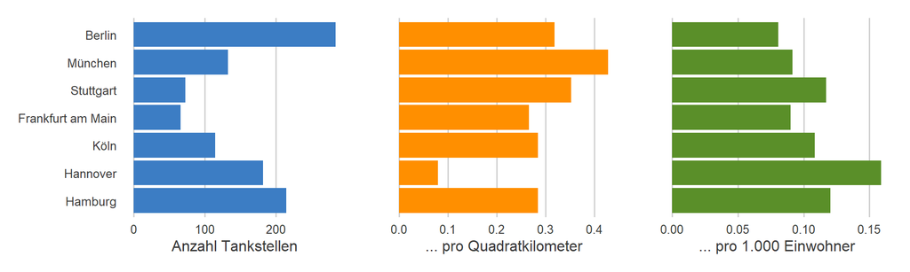

```r
  # query data
  query_city7 <- paste0("
                    SELECT
                      pop.kreis_kz,
                      stations.kreis_name,
                      count,
                      pop.pop_kreis,
                      area.area_kreis,
                      round(count/area.area_kreis, 4) AS a_dens,
                      round(count*1000/pop.pop_kreis, 4) AS p_dens
                    FROM
                      (SELECT
                          kreis_kz,
                          pop_kreis
                       FROM
                          pop_kreis
                       WHERE
                          date = '", year, "-12-31'
                       AND
                          pop_kreis IS NOT NULL
                      ORDER BY
                          pop_kreis DESC
                      LIMIT 7) pop
                    LEFT JOIN
                      (SELECT
                          kreis_kz,
                          kreis_name,
                          count(*) AS count
                       FROM
                          stations
                       WHERE
                          uuid = ANY('{",act_stations_string ,"}')
                       GROUP BY
                          kreis_kz,
                          kreis_name) stations
                    ON
                      pop.kreis_kz = stations.kreis_kz
                    LEFT JOIN
                      (SELECT
                          kreis_kz,
                          area_kreis
                      FROM
                          area_kreis
                      WHERE
                          date = '", year, "-12-31') area
                    ON
                      pop.kreis_kz = area.kreis_kz
                    ORDER BY
                      pop.kreis_kz ASC;")

  stations_city7 <- dbGetQuery(dbcon, query_city7) %>%
    as_tibble() %>%
    mutate(kreis_name = factor(kreis_name, kreis_name))

  # plot number of stations by city
  stations_city7_plot <- ggplot(data = stations_city7, mapping = aes(x = kreis_name, y = count)) +
    geom_bar(stat = "identity",
             show.legend = F,
             width = 0.9,
             fill = colors[3],
             alpha = 1) +
    #geom_text(aes(label = count), # add for printing actual numbers to bars
    #          hjust = if_else(stations_city7$count >= 0.7*max(stations_city7$count), 1.2, -0.1),
    #          color = if_else(stations_city7$count >= 0.7*max(stations_city7$count), "white", "black"),
    #          position = position_dodge(0.9), size = 3.5) +
    theme_base() +
    labs(x = NULL, y = "Anzahl Tankstellen") +
    coord_flip()

  # plot number of stations per square kilometer by city
  area_city7_plot <- ggplot(data = stations_city7, mapping = aes(x = kreis_name, y = a_dens)) +
    geom_bar(stat = "identity",
             show.legend = F,
             width = 0.9,
             fill = colors[1],
             alpha = 1) +
    #geom_text(aes(label = round(a_dens, 2)), # add for printing actual numbers to bars
    #          hjust = if_else(stations_city7$a_dens >= 0.7*max(stations_city7$a_dens), 1.2, -0.1),
    #          color = "black",
    #          position = position_dodge(0.9), size = 3.5) +
    theme_base() +
    labs(x = NULL, y = "... pro Quadratkilometer") +
    coord_flip() +
    scale_x_discrete(labels = rep("",dim(stations_city7)[1]))

  # plot number of stations per population by city
  pop_city7_plot <- ggplot(data = stations_city7, mapping = aes(x = kreis_name, y = p_dens)) +
    geom_bar(stat = "identity",
             show.legend = F,
             width = 0.9,
             fill = colors[2],
             alpha = 1) +
    #geom_text(aes(label = round(p_dens, 2)), # add for printing actual numbers to bars
    #          hjust = if_else(stations_city7$p_dens >= 0.7*max(stations_city7$p_dens), 1.2, -0.1),
    #          color = if_else(stations_city7$p_dens >= 0.7*max(stations_city7$p_dens), "white", "black"),
    #          position = position_dodge(0.9), size = 3.5) +
    theme_base() +
    labs(x = NULL, y = "... pro 1.000 Einwohner") +
    coord_flip() +
    scale_x_discrete(labels = rep("",dim(stations_city7)[1]))

  # arrange plots
  grid.arrange(stations_city7_plot, area_city7_plot, pop_city7_plot,
               ncol = 3,
               widths = c(4,3,3))
```

## nach Landkreisen

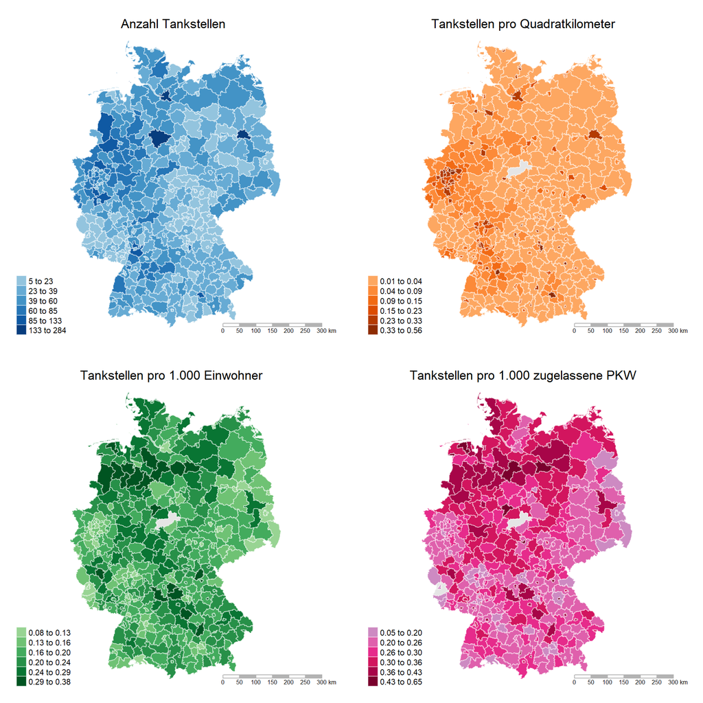

```r
  # load map county map data
  county_shp_in <- readOGR(dsn = "data/map2019/vg250_ebenen",
                           layer="VG250_KRS", encoding = "UTF-8",
                           stringsAsFactors = F, verbose = F, use_iconv = T)

  # query county data
  query_county <- paste0("
                    SELECT
                      stations.kreis_kz,
                      stations.kreis_name,
                      count,
                      area.area_kreis,
                      pop.pop_kreis,
                            cars.kfz,
                            cars.lkw,
                      round(count/area.area_kreis, 4) AS a_dens,
                      round(count*1000/pop.pop_kreis, 4) AS p_dens,
                            round(count*1000/cars.kfz::decimal, 4) AS kfz_dens,
                            round(count*1000/cars.lkw::decimal, 4) AS lkw_dens
                    FROM
                      (SELECT
                          kreis_kz,
                          kreis_name,
                          count(*) AS count
                       FROM
                          stations_test
                       WHERE
                          kreis_kz IS NOT NULL
                       AND
                          uuid = ANY('{",act_stations_string ,"}')
                       GROUP BY
                          kreis_kz,
                          kreis_name) stations
                    LEFT JOIN
                      (SELECT
                          kreis_kz,
                          area_kreis
                       FROM
                          area_kreis
                         WHERE
                            date = '", year, "-12-31') area
                    ON
                      stations.kreis_kz = area.kreis_kz
                    LEFT JOIN
                      (SELECT
                          kreis_kz,
                          pop_kreis
                       FROM
                          pop_kreis
                         WHERE
                            date = '", year, "-12-31') pop
                    ON
                      stations.kreis_kz = pop.kreis_kz
                    LEFT JOIN
                      (SELECT
                          kreis_kz,
                          kfz,
                          lkw
                       FROM
                          car_numbers
                         WHERE
                            date = '", year, "-01-01') cars
                    ON
                      stations.kreis_kz = cars.kreis_kz
                    ORDER BY
                            kreis_kz ASC;")

  stations_county <- dbGetQuery(dbcon, query_county) %>%
    as_tibble()

  # join map data and queried data
  county_shp <- county_shp_in
  county_shp@data <- county_shp_in@data %>%
    left_join(stations_county, by = c("AGS" = "kreis_kz"))

  # map number of stations
  map_kreise_count <- tm_shape(shp = county_shp, name = "Anzahl Tankstellen") +
    tm_polygons("count",
                style = "jenks",
                palette = "Blues", n = 6, contrast = c(0.4, 0.95),
                border.col = "white",
                border.alpha = 0.5,
                title = "",
                id = "GEN",
                legend.format = list(digits = 0),
                showNA = F,
                colorNA = "grey90",
                popup.vars = c("Number stations:" = "count"),
                popup.format = list(digits = 0)) +
    tm_layout(title = "Anzahl Tankstellen",
              title.size = 1.1,
              title.position = c("center","top"),
              inner.margins = c(0.05,0.10,0.10,0.10),
              legend.position = c("left","bottom"),
              frame  = F) +
    tm_scale_bar(color.dark = "gray70",
                 position = c("right","bottom"))

  # map number of station per square kilometer
  map_kreise_area <- tm_shape(shp = county_shp, name = "Tankstellen pro Quadratkilometer") +
    tm_polygons("a_dens",
                style = "jenks",
                palette = "Oranges", n = 6, contrast = c(0.4, 0.95),
                border.col = "white",
                border.alpha = 0.5,
                title = "",
                id = "GEN",
                legend.format = list(digits = 2),
                showNA = F,
                colorNA = "grey90",
                popup.vars = c("Number stations:" = "a_dens"),
                popup.format = list(digits = 2)) +
    tm_layout(title = "Tankstellen pro Quadratkilometer",
              title.size = 1.1,
              title.position = c("center","top"),
              inner.margins = c(0.05,0.10,0.10,0.10),
              legend.position = c("left","bottom"),
              frame  = F) +
    tm_scale_bar(color.dark = "gray70",
                 position = c("right","bottom"))

    # map number of stations per 1.000 population
    map_kreise_pop <- tm_shape(shp = county_shp, name = "Tankstellen pro 1.000 Einwohner") +
    tm_polygons("p_dens",
                style = "jenks",
                palette = "Greens", n = 6, contrast = c(0.4, 0.95),
                border.col = "white",
                border.alpha = 0.5,
                title = "",
                id = "GEN",
                legend.format = list(digits = 2),
                showNA = F,
                colorNA = "grey90",
                popup.vars = c("Number stations:" = "p_dens"),
                popup.format = list(digits = 2)) +
    tm_layout(title = "Tankstellen pro 1.000 Einwohner",
              title.size = 1.1,
              title.position = c("center","top"),
              inner.margins = c(0.05,0.10,0.10,0.10),
              legend.position = c("left","bottom"),
              frame  = F) +
    tm_scale_bar(color.dark = "gray70",
                 position = c("right","bottom"))

  # map number of stations per 1.000 cars
  map_kreise_cars <- tm_shape(shp = county_shp, name = "Tankstellen pro 1.000 zugelassene PKW") +
    tm_polygons("kfz_dens",
                style = "jenks",
                palette = "PuRd", n = 6, contrast = c(0.4, 0.95),
                border.col = "white",
                border.alpha = 0.5,
                title = "",
                id = "GEN",
                legend.format = list(digits = 2),
                showNA = F,
                colorNA = "grey90",
                popup.vars = c("Number stations:" = "kfz_dens"),
                popup.format = list(digits = 2)) +
    tm_layout(title = "Tankstellen pro 1.000 zugelassene PKW",
              title.size = 1.1,
              title.position = c("center","top"),
              inner.margins = c(0.05,0.10,0.10,0.10),
              legend.position = c("left","bottom"),
              frame  = F) +
    tm_scale_bar(color.dark = "gray70",
                 position = c("right","bottom"))

  # arrange maps
  tmap_arrange(map_kreise_count, map_kreise_area, map_kreise_pop, map_kreise_cars,
               ncol = 2, nrow = 2)
```

## nach Marken

Die Marken der einzelnen Tankstellen sind im Datensatz von Tankerkönig nicht immer eindeutig benannt. Die Zuordnung der Tankstellen zu den jeweiligen Marken erfolgte daher mittels automatischer Textmustererkennung. Daher sind gewisse Fehlzuordnungen nicht auszuschließen. Ein stichprobenartiger Vergleich zeigt jedoch, dass die automatische Zuordnung nahe an der Realität liegt.

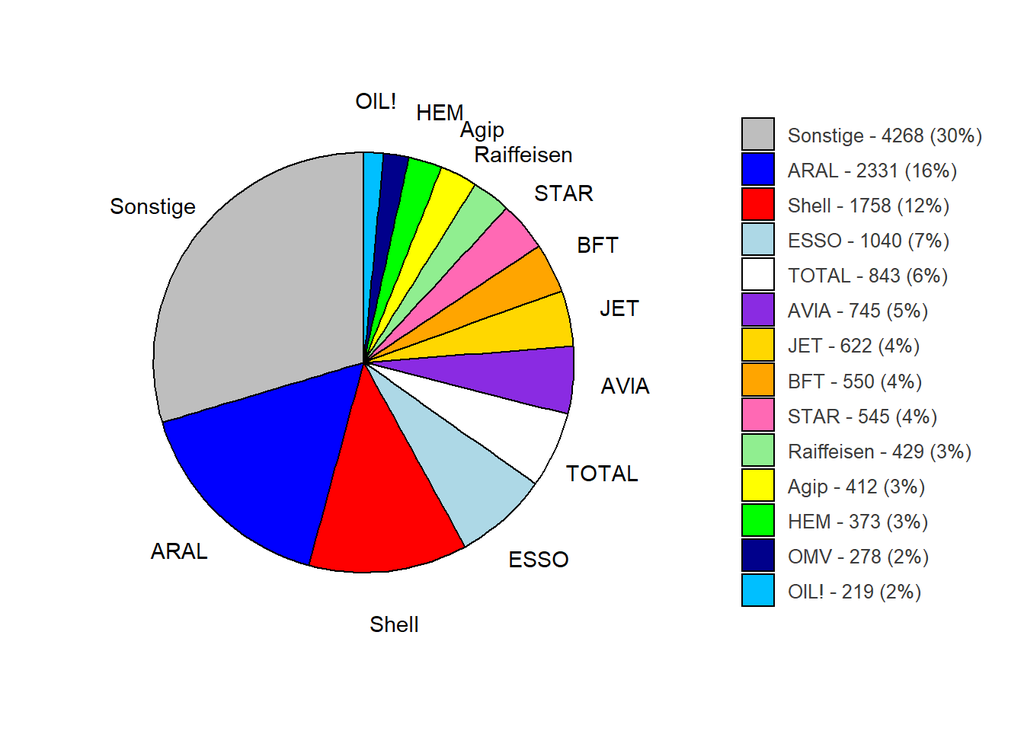

```r
  # query brands in dataset
  query_brands <- paste0("
                    SELECT
                      distinct(brand_cat),
                      count(*)
                    FROM
                      stations_test
                    WHERE
                      uuid = ANY('{",act_stations_string ,"}')
                    GROUP BY
                      brand_cat;")

  # tidy data, assign brand colors, calc shares
  brands <- dbGetQuery(dbcon, query_brands) %>%
    as_tibble() %>%
    arrange(brand_cat) %>%
    add_column(color = c("yellow","blue","blueviolet","orange",
                         "lightblue","green","gold","deepskyblue",
                         "darkblue","lightgreen","red","grey",
                         "hotpink","white")) %>%
    arrange(desc(count)) %>%
    mutate(brand_cat = factor(brand_cat, brand_cat)) %>%
    mutate(ypos = sum(count) - cumsum(count) + count - 0.5*count) %>%
    mutate(share = count/sum(count)*100)

  # plot brand shares
  ggplot(data = brands, mapping = aes(x = "", y = count, fill = brand_cat)) +
      geom_bar(stat = "identity",
               color = "black",
               show.legend = T,
               width = 1) +
      labs(x = NULL, y = NULL) +
      scale_fill_manual(values = brands$color, name = "",
                        labels = paste(brands$brand_cat, " - ", brands$count, " (", round(brands$share,0), "%)", sep = ""),
                        guide = guide_legend(ncol = 1)) +
      coord_polar(theta = "y", start = 0) +
      geom_text(aes(y = ypos, label = brand_cat, x = 1.75),
                check_overlap = T) +
      theme_base() +
      theme(panel.grid.major.x = element_blank(),
          axis.text = element_blank(),
          legend.position = "right")
```

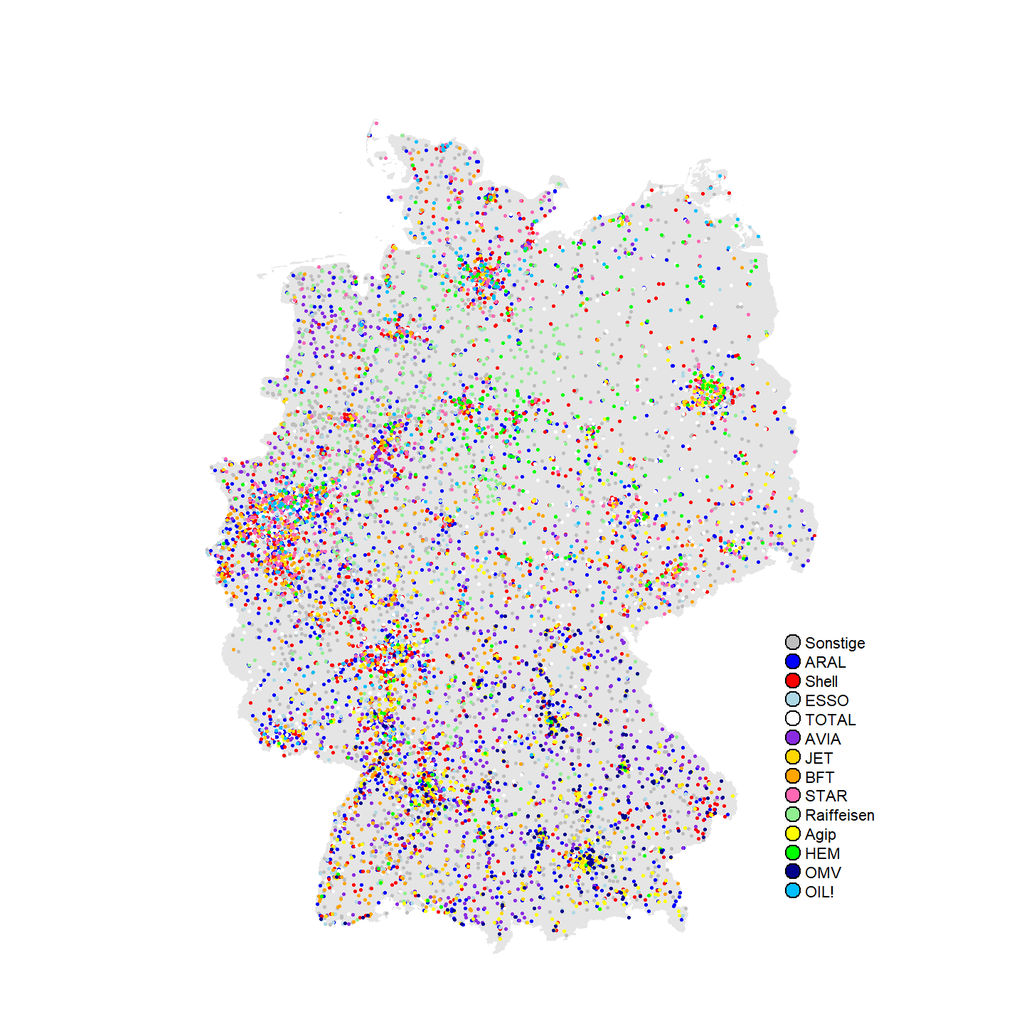

```r
  # query stations, long, lat
  query_stations_pos <- paste("SELECT brand_cat, longitude, latitude FROM stations_test
                               WHERE uuid = ANY('{",act_stations_string ,"}')", sep = "")

  stations_pos <- dbGetQuery(dbcon, query_stations_pos) %>%
    as_tibble() %>%
    filter(longitude != 0, longitude < 20, latitude > 40)

  # map position of stations, colour by brand
  map_stations_pos <- tm_shape(county_shp) +
    tm_fill(col = "grey90")

  for(i in 1:length(brands$brand_cat)){ # transform geodata
    temp_stations_pos <- stations_pos %>%
      filter(brand_cat == brands$brand_cat[i])

    temp_pos_shp <- st_as_sf(temp_stations_pos, coords = c("longitude","latitude"), crs = 4979)

    map_stations_pos <- map_stations_pos +
      tm_shape(temp_pos_shp) +
      tm_dots(col = brands$color[i],
              border.lwd = NA,
              scale = 1.3)
  }

  map_stations_pos <- map_stations_pos +
    tm_add_legend(type = "symbol",
                  labels = brands$brand_cat,
                  col = brands$color) +
    tm_layout(title = "",
              title.position = c("center","top"),
              inner.margins = c(0.05,0.10,0.10,0.10),
              frame = F,
              legend.position = c(0.85,0.1))

  map_stations_pos
```

# Preise

Die dargestellten Preisinformationen beruhen auf den von den Tankstellen gemeldeten Preisänderungen. Jede gemeldete Preisänderung geht mit gleichem Gewicht in die Berechnung von Durchschnittspreisen ein. Es erfolgt keine keine Gewichtung nach Absatzmenge oder Zeit in der der gemeldete Preis aktiv war. Dies führt dazu, dass beispielsweise mehrere Meldungen von Preisänderungen auf vergleichsweise hohem Preisniveau in kurzen Zeitabständen die berechneten Durchschnittspreise nach oben verzerren. Gleiches gilt für häufige Preisänderungen auf vergleichsweise niedrigem Niveau.

## Regionale Preisverteilung nach Landkreisen

```r
  # Query monthly price data by county
  query_month_county <- paste0("
                    SELECT
                      kreis_kz,
                      kreis_name,
                      month,
                      round(AVG(pe5),3) AS pe5,
                      round(AVG(pe10),3) AS pe10,
                      round(AVG(pdi),3) AS pdi,
                      count(*) AS anzahl
                    FROM
                      ((SELECT
                              stid,
                              date_trunc('month', time) as month,
                              round(avg(pe5),3) AS pe5,
                              round(avg(pe10),3) AS pe10,
                              round(avg(pdi),3) AS pdi
                          FROM
                            price
                          WHERE
                            time BETWEEN '", year, "-01-01 00:00:01'
                                 AND '", year, "-12-31 23:59:59'
                          GROUP BY
                            stid, month) price
                    INNER JOIN
                      stations_test
                    ON
                      stations_test.uuid = price.stid)
                    GROUP BY
                      kreis_kz,
                      kreis_name,
                      month;")

  price_month_county <- dbGetQuery(dbcon, query_month_county) %>%
    as_tibble()

  # calc breaks for map legend
  breaks_price_month_county <- list(pe5 = seq(floor(min(price_month_county$pe5, na.rm = T)*100)/100,
                                                ceiling(max(price_month_county$pe5, na.rm = T)*100)/100,
                                                by = 0.01),
                                      pe10 = seq(floor(min(price_month_county$pe10, na.rm = T)*100)/100,
                                                 ceiling(max(price_month_county$pe10, na.rm = T)*100)/100,
                                                 by = 0.01),
                                      pdi = seq(floor(min(price_month_county$pdi, na.rm = T)*100)/100,
                                                ceiling(max(price_month_county$pdi, na.rm = T)*100)/100,
                                                by = 0.01))

  # tidy data
  price_month_county <- price_month_county %>%
    pivot_wider(names_from = month, values_from = c(pe5, pe10, pdi, anzahl))

  # join with map data
  price_month_county_shp <- county_shp_in
  price_month_county_shp@data <- price_month_county_shp@data %>%
      left_join(price_month_county, by = c("AGS" = "kreis_kz"))

  # map monthly prices by county - Super E5
  map_price_month_county_pe5 <- tm_shape(shp = price_month_county_shp, name = "Monthly Super E5 Price") +
      tm_polygons(paste0("pe5_", seq(as.Date(paste0(year, "-01-01")), by = "month", length.out = 12)),
                  style = "fixed",
                  palette = "Blues", contrast = c(0.3, 1.0),
                  breaks = breaks_price_month_county$pe5,
                  border.col = "white",
                  border.alpha = 0.5,
                  title = "",
                  id = "GEN",
                  legend.show = F,
                  showNA = F,
                  colorNA = "grey90") +
      tm_facets(nrow = 4) +
      tm_layout(title = format(seq(ISOdate(2000,1,1), by = "month", length.out = 12), "%B"),
                title.size = 1.7,
                title.position = c("center","top"),
                inner.margins = c(0.06,0.10,0.10,0.10),
                frame  = F)

  legend_map_pe5 <- tm_shape(shp = price_month_county_shp) +
    tm_fill(paste0("pe5_", year, "-01-01"),
            style = "fixed",
            palette = "Blues", contrast = c(0.3, 1.0),
            breaks = breaks_price_month_county$pe5,
            title = "Preis Super E5 in €",
            legend.format = list(digits = 2)) +
    tm_layout(legend.only = T,
              legend.height = 6,
              legend.width = 2,
              asp = 0,
              scale = 1.3)

  # map monthly prices by county - Super E10
  map_price_month_county_pe10 <- tm_shape(shp = price_month_county_shp, name = "Monthly Super E10 Price") +
      tm_polygons(paste0("pe10_", seq(as.Date(paste0(year, "-01-01")), by = "month", length.out = 12)),
                  style = "fixed",
                  palette = "Oranges", contrast = c(0.3, 1.0),
                  breaks = breaks_price_month_county$pe10,
                  border.col = "white",
                  border.alpha = 0.5,
                  title = "",
                  id = "GEN",
                  legend.show = F,
                  showNA = F,
                  colorNA = "grey90") +
      tm_facets(nrow = 4) +
      tm_layout(title = format(seq(ISOdate(2000,1,1), by = "month", length.out = 12), "%B"),
                title.size = 1.7,
                title.position = c("center","top"),
                inner.margins = c(0.06,0.10,0.10,0.10),
                frame  = F)

  legend_map_pe10 <- tm_shape(shp = price_month_county_shp) +
    tm_fill(paste0("pe10_", year, "-01-01"),
            style = "fixed",
            palette = "Oranges", contrast = c(0.3, 1.0),
            breaks = breaks_price_month_county$pe10,
            title = "Preis Super E10 in €",
            legend.format = list(digits = 2)) +
    tm_layout(legend.only = T,
              legend.height = 6,
              legend.width = 2,
              asp = 0,
              scale = 1.3)

  # map monthly prices by county - Diesel
  map_price_month_county_pdi <- tm_shape(shp = price_month_county_shp, name = "Monthly Diesel Price") +
      tm_polygons(paste0("pdi_", seq(as.Date(paste0(year, "-01-01")), by = "month", length.out = 12)),
                  style = "fixed",
                  palette = "Greens", contrast = c(0.3, 1.0),
                  breaks = breaks_price_month_county$pdi,
                  border.col = "white",
                  border.alpha = 0.5,
                  title = "",
                  id = "GEN",
                  legend.show = F,
                  showNA = F,
                  colorNA = "grey90") +
      tm_facets(nrow = 4) +
      tm_layout(title = format(seq(ISOdate(2000,1,1), by = "month", length.out = 12), "%B"),
                title.size = 1.7,
                title.position = c("center","top"),
                inner.margins = c(0.06,0.10,0.10,0.10),
                frame  = F)

  legend_map_pdi <- tm_shape(shp = price_month_county_shp) +
    tm_fill(paste0("pdi_", year, "-01-01"),
            style = "fixed",
            palette = "Greens", contrast = c(0.3, 1.0),
            breaks = breaks_price_month_county$pdi,
            title = "Preis Diesel in €",
            legend.format = list(digits = 2)) +
    tm_layout(legend.only = T,
              legend.height = 6,
              legend.width = 2,
              asp = 0,
              scale = 1.3)

  # box plots by months
  query_percentiles_month_county <- paste0("
                    SELECT
                      date_trunc('month', time) AS month,
                      unnest(percentile_cont(ARRAY[0.05, 0.25, 0.5, 0.75, 0.95])
                        within group (order by pe5)) AS pe5,
                      unnest(percentile_cont(ARRAY[0.05, 0.25, 0.5, 0.75, 0.95])
                        within group (order by pe10)) AS pe10,
                      unnest(percentile_cont(ARRAY[0.05, 0.25, 0.5, 0.75, 0.95])
                        within group (order by pdi)) AS pdi,
                      unnest(ARRAY[0.05, 0.25, 0.5, 0.75, 0.95]) AS perc
                    FROM
                      price
                    WHERE
                      time BETWEEN '", year, "-01-01 00:00:01'
                           AND '", year, "-12-31 23:59:59'
                    GROUP BY
                      month;")

  pricePercentilesMonthCounty <- dbGetQuery(dbcon, query_percentiles_month_county) %>%
    as_tibble()

  # tidy data
  pricePercentilesMonthCounty_plot <- pricePercentilesMonthCounty %>%
    mutate(month = format(month, "%B")) %>%
    pivot_wider(names_from = perc, values_from = c(pe5, pe10, pdi)) %>%
    mutate(month = factor(month, month))

  # box plot super E5 by month
  boxPlotSuperE5 <- ggplot(pricePercentilesMonthCounty_plot, aes(x = month)) +
    geom_boxplot(
      aes(ymin = pe5_0.05, lower = pe5_0.25, middle = pe5_0.5, upper = pe5_0.75, ymax = pe5_0.95),
      stat = "identity",
      fill = colors[3],
      width = 0.8) +
    theme_base() +
    theme(panel.grid.major.x = element_blank(),
          panel.grid.major.y = element_line(linetype = 2, colour = "grey55")) +
    labs(x = NULL, y = "Preis Super E5 in Euro") +
    scale_y_continuous(name = "Preis Super E5 in Euro",
                       expand = expansion(add = 0.02))

  # box plot Super E10 by month
  boxPlotSuperE10 <- ggplot(pricePercentilesMonthCounty_plot, aes(x = month)) +
    geom_boxplot(
      aes(ymin = pe10_0.05, lower = pe10_0.25, middle = pe10_0.5, upper = pe10_0.75, ymax = pe10_0.95),
      stat = "identity",
      fill = colors[1],
      width = 0.8) +
    theme_base() +
    theme(panel.grid.major.x = element_blank(),
          panel.grid.major.y = element_line(linetype = 2, colour = "grey55")) +
    labs(x = NULL, y = "Preis Super E10 in Euro") +
    scale_y_continuous(name = "Preis Super E10 in Euro",
                       expand = expansion(add = 0.02))

  # box plot Super E10 by month
  boxPlotDiesel <- ggplot(pricePercentilesMonthCounty_plot, aes(x = month)) +
    geom_boxplot(
      aes(ymin = pdi_0.05, lower = pdi_0.25, middle = pdi_0.5, upper = pdi_0.75, ymax = pdi_0.95),
      stat = "identity",
      fill = colors[2],
      width = 0.8) +
    theme_base() +
    theme(panel.grid.major.x = element_blank(),
          panel.grid.major.y = element_line(linetype = 2, colour = "grey55")) +
    labs(x = NULL, y = "Preis Diesel in Euro") +
    scale_y_continuous(name = "Preis Diesel in Euro",
                       expand = expansion(add = 0.02))
```

### Super E5

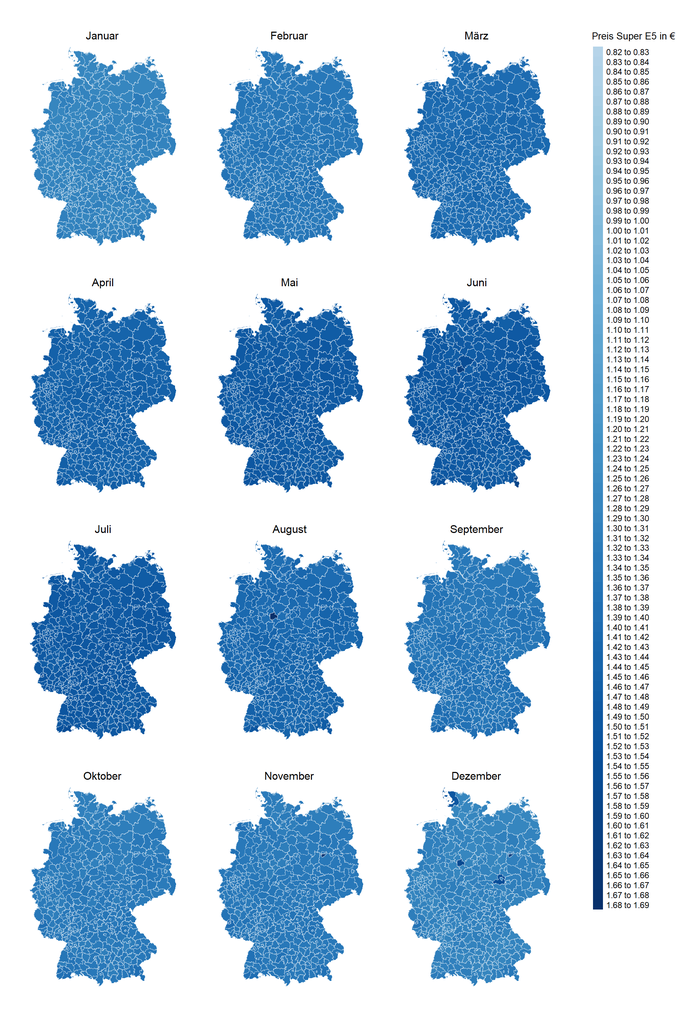

```r
  tmap_arrange(map_price_month_county_pe5, legend_map_pe5, ncol = 2, widths = c(0.85, 0.15))
```

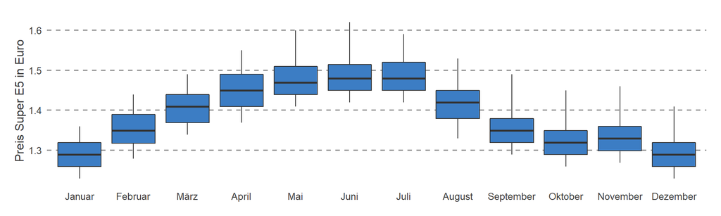

```r
  boxPlotSuperE5
```

Anmerkung: Dargestellt sind Median sowie 5%, 25%, 75% und 95% Quantile.

### Super E10

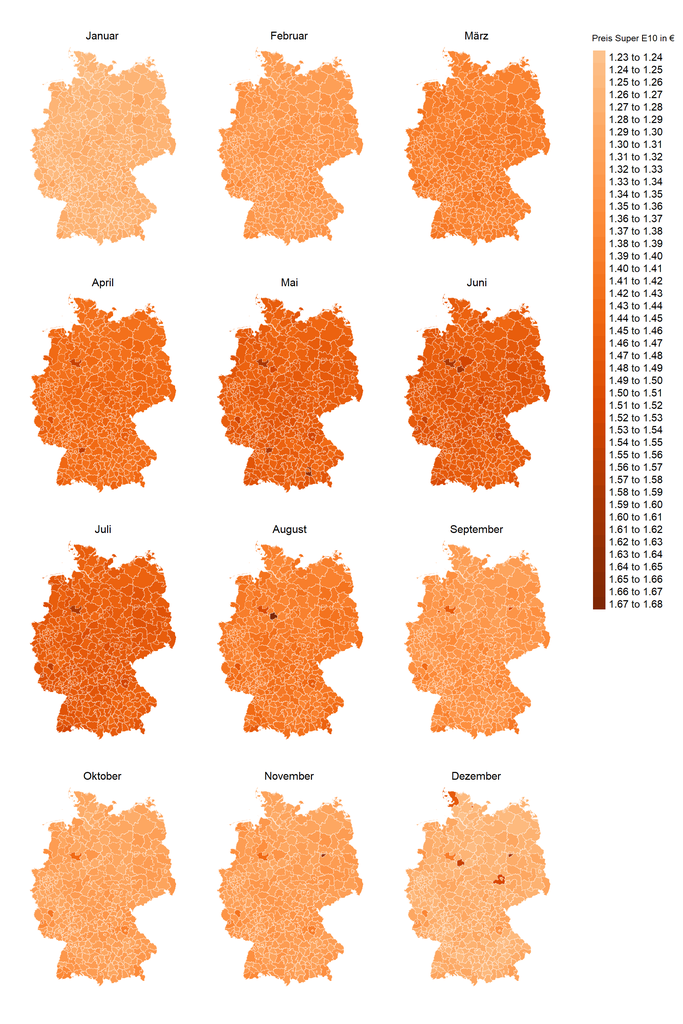

```r
  tmap_arrange(map_price_month_county_pe10, legend_map_pe10, ncol = 2, widths = c(0.85, 0.15))
```

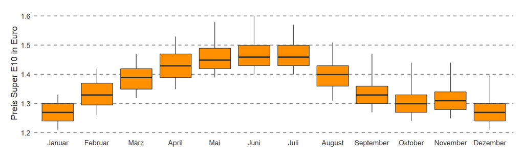

```r
  boxPlotSuperE10
```

Anmerkung: Dargestellt sind Median sowie 5%, 25%, 75% und 95% Quantile.

### Diesel

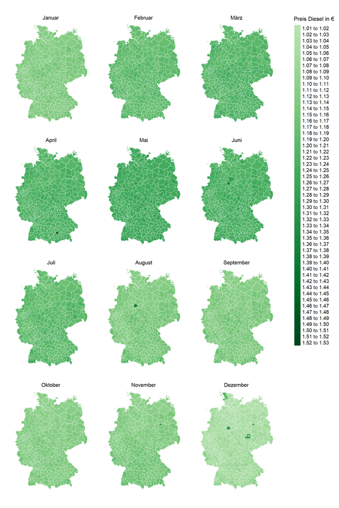

```r
  tmap_arrange(map_price_month_county_pdi, legend_map_pdi, ncol = 2, widths = c(0.85, 0.15))
```

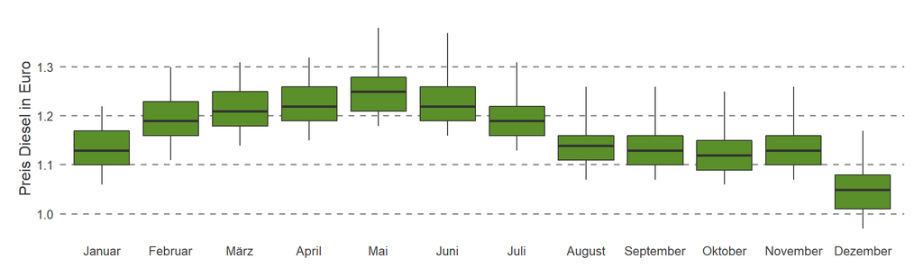

```r
  boxPlotDiesel
```

Anmerkung: Dargestellt sind Median sowie 5%, 25%, 75% und 95% Quantile.

## Preisentwicklung

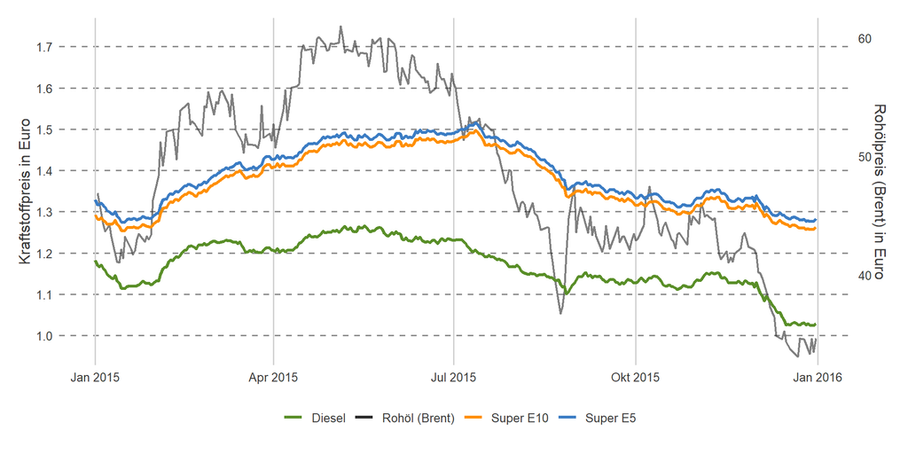

```r
  # query daily average price
  query_price_day <- paste0("
                    SELECT
                      time_bucket('1 day', time::TIMESTAMP) AS day,
                      round(avg(pe5),3) AS e5,
                      round(avg(pe10),3) AS e10,
                      round(avg(pdi),3) AS diesel
                    FROM
                      price
                    WHERE
                      time BETWEEN '", year, "-01-01 00:00:01'
                           AND '", year, "-12-31 23:59:59'
                    GROUP BY
                      day
                    ORDER BY
                      day ASC;")

  prices_day <- dbGetQuery(dbcon, query_price_day) %>%
    as_tibble() %>%
    mutate(day = as.Date(day))

  # load brent prices
  brent_in <- read_delim(file = "data/brent.csv",
                      delim = ";",
                      locale = locale(decimal_mark = ","))

  brent <- brent_in %>%
    mutate(Datum = as.Date(Datum, "%d.%m.%Y")) %>%
    arrange(Datum) %>%
    filter(Datum >= paste0(year, "-01-01")) %>%
    filter(Datum <= paste0(year, "-12-31"))

  # adjustementfactor for second axis plot
  adjFactorBrent <- mean(brent$Schluss) / mean(c(mean(prices_day$e5), mean(prices_day$e5)))

  # plot daily prices fuel and oil
  ggplot(prices_day, aes(x = day)) +
    geom_line(data = brent,
              mapping = aes(x = Datum, y = Schluss / adjFactorBrent, colour = "Rohöl (Brent)"),
              size = 0.8,
              alpha = 0.6) +
    geom_line(aes(y = e5, colour = "Super E5"),
              size = 1.2) +
    geom_line(aes(y = e10, colour = "Super E10"),
              size = 1.2) +
    geom_line(aes(y = diesel, colour = "Diesel"),
              size = 1.2) +
    theme_base() +
    theme(panel.grid.major.y = element_line(linetype = 2, colour = "grey55")) +
    labs(x = NULL, y = "Kraftstoffpreis in Euro") +
    scale_y_continuous(expand = expansion(add = 0.02),
                       n.breaks = 8,
                       sec.axis = sec_axis(~.*adjFactorBrent, name = "Rohölpreis (Brent) in Euro")) +
    scale_colour_manual("",
                        values = c("Rohöl (Brent)" = colors[4], "Super E5" = colors[3],
                                   "Super E10" = colors[1], "Diesel" = colors[2]))
```

## Preisunterschiede: Super E5 im Vergleich zu Super E10 und Diesel

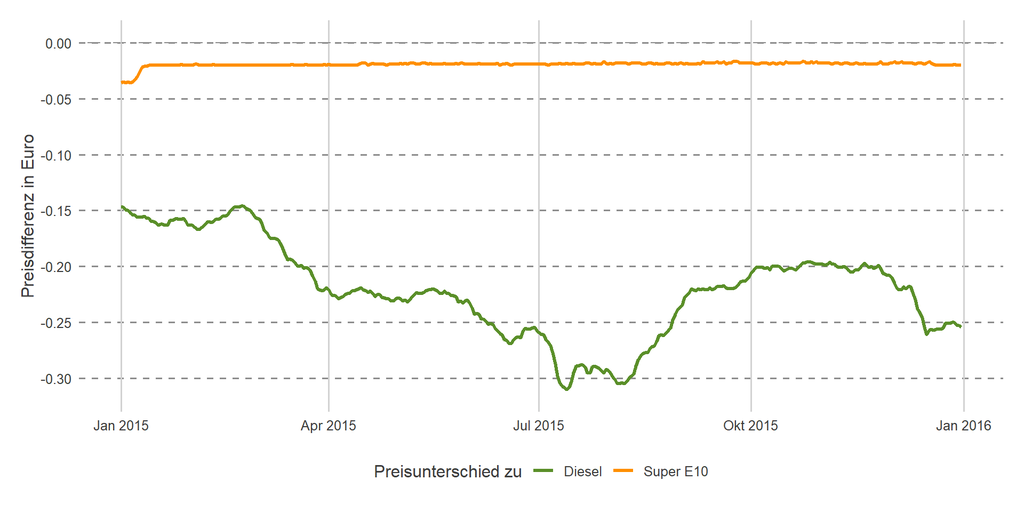

```r
  # calc price differences Super E10 and Diesel to Super E5
  prices_day_diff <- prices_day %>%
    mutate(diff_e5_e10 = e10 - e5,
           diff_e5_diesel = diesel - e5)

  # plot price differences
  ggplot(prices_day_diff, aes(x = day)) +
    geom_line(aes(y = diff_e5_e10, colour = "Super E10"),
              size = 1.2) +
    geom_line(aes(y = diff_e5_diesel, colour = "Diesel"),
              size = 1.2) +
    theme_base() +
    theme(panel.grid.major.y = element_line(linetype = 2, colour = "grey55")) +
    labs(x = NULL, y = "Preisdifferenz in Euro") +
    scale_y_continuous(expand = expansion(add = 0.02),
                       n.breaks = 8) +
    scale_colour_manual("Preisunterschied zu",
                        values = c("Super E10" = colors[1], "Diesel" = colors[2])) +
    geom_hline(yintercept = 0, lty = 2, colour = "grey55")
```

## Disaggregierte Preisentwicklung: Super E5

```r
  # query stations, bl_kz, brand_cat, street_cat
  query_stations_cat <- paste0("
                    SELECT
                      uuid,
                      bl_kz,
                      kreis_kz,
                      brand_cat,
                      street_cat
                    FROM
                      stations_test
                    WHERE
                      uuid = ANY('{",act_stations_string ,"}');")

  stations_cat <- dbGetQuery(dbcon, query_stations_cat) %>%
    as_tibble()

  # query raumtyp
  query_raumtyp <- paste0("
                    SELECT
                      krs17 as kreis_kz,
                      slraum
                    FROM
                      bbsr_kreise_2017;")

  raumtyp <- dbGetQuery(dbcon, query_raumtyp) %>%
    as_tibble() %>%
    mutate(kreis_kz = str_sub(kreis_kz, 1, 5))

  # join stations with raumtyp
  stations_cat <- stations_cat %>%
    left_join(raumtyp)

  # create list with ID's for different groups
  stations_cat_ids_full <- list(autobahn = stations_cat %>%
                             filter(street_cat == "Autobahn"),
                           autohof = stations_cat %>%
                             filter(street_cat == "Autohof"),
                           normal = stations_cat %>%
                             filter(street_cat == "Sonstige"),
                           aral = stations_cat %>%
                             filter(brand_cat == "ARAL") %>%
                             filter(street_cat == "Sonstige"),
                           shell = stations_cat %>%
                             filter(brand_cat == "Shell") %>%
                             filter(street_cat == "Sonstige"),
                           hem = stations_cat %>%
                             filter(brand_cat == "HEM") %>%
                             filter(street_cat == "Sonstige"),
                           jet = stations_cat %>%
                             filter(brand_cat == "JET") %>%
                             filter(street_cat == "Sonstige"),
                           north = stations_cat %>%
                             filter(bl_kz == "01" | bl_kz == "02" |
                                    bl_kz == "03" | bl_kz == "04") %>%
                             filter(street_cat == "Sonstige"),
                           east = stations_cat %>%
                             filter(bl_kz == "11" | bl_kz == "12" |
                                    bl_kz == "13" | bl_kz == "14" |
                                    bl_kz == "15" | bl_kz == "16") %>%
                             filter(street_cat == "Sonstige"),
                           south = stations_cat %>%
                             filter(bl_kz == "08" | bl_kz == "09") %>%
                             filter(street_cat == "Sonstige"),
                           west = stations_cat %>%
                             filter(bl_kz == "05" | bl_kz == "06" |
                                    bl_kz == "07" | bl_kz == "10") %>%
                             filter(street_cat == "Sonstige"),
                           city = stations_cat %>%
                             filter(slraum == 1) %>%
                             filter(street_cat == "Sonstige"),
                           rural = stations_cat %>%
                             filter(slraum == 2) %>%
                             filter(street_cat == "Sonstige"))

  # collapse strings for query
  stations_cat_ids <- list(autobahn = paste(stations_cat_ids_full$autobahn$uuid , collapse = ","),
                           autohof = paste(stations_cat_ids_full$autohof$uuid, collapse = ","),
                           normal = paste(stations_cat_ids_full$normal$uuid, collapse = ","),
                           aral = paste(stations_cat_ids_full$aral$uuid, collapse = ","),
                           shell = paste(stations_cat_ids_full$shell$uuid, collapse = ","),
                           hem = paste(stations_cat_ids_full$hem$uuid, collapse = ","),
                           jet = paste(stations_cat_ids_full$jet$uuid, collapse = ","),
                           north = paste(stations_cat_ids_full$north$uuid, collapse = ","),
                           east = paste(stations_cat_ids_full$east$uuid, collapse = ","),
                           south = paste(stations_cat_ids_full$south$uuid, collapse = ","),
                           west= paste(stations_cat_ids_full$west$uuid, collapse = ","),
                           city = paste(stations_cat_ids_full$city$uuid, collapse = ","),
                           rural = paste(stations_cat_ids_full$rural$uuid, collapse = ","))

  # query autobahn price
  query_autobahn_price <- paste0("
                    SELECT
                      time_bucket('1 day', time::TIMESTAMP) as day,
                      round(avg(pe5),3) as e5,
                      round(avg(pe10),3) as e10,
                      round(avg(pdi),3) as diesel
                    FROM
                      price
                    WHERE
                      (stid = ANY('{",stations_cat_ids$autobahn ,"}'))
                    AND
                      (time BETWEEN '", year, "-01-01 00:00:01'
                            AND '", year, "-12-31 23:59:59')
                    GROUP BY
                      day
                    ORDER BY
                      day ASC;")

  # query autohof price
  query_autohof_price <- paste0("
                    SELECT
                      time_bucket('1 day', time::TIMESTAMP) as day,
                      round(avg(pe5),3) as e5,
                      round(avg(pe10),3) as e10,
                      round(avg(pdi),3) as diesel
                    FROM
                      price
                    WHERE
                      (stid = ANY('{",stations_cat_ids$autohof ,"}'))
                    AND
                      (time BETWEEN '", year, "-01-01 00:00:01'
                            AND '", year, "-12-31 23:59:59')
                    GROUP BY
                      day
                    ORDER BY
                      day ASC;")
```

```r
  # query 'normal' stations price (split due to memory constraints)
  query_normal_price1 <- paste0("
                    SELECT
                      time_bucket('1 day', time::TIMESTAMP) as day,
                      round(avg(pe5),3) as e5,
                      round(avg(pe10),3) as e10,
                      round(avg(pdi),3) as diesel
                    FROM
                      price
                    WHERE
                      (stid = ANY('{",stations_cat_ids$normal,"}'))
                    AND
                      (time BETWEEN '", year, "-01-01 00:00:01'
                            AND '", year, "-06-30 23:59:59')
                    GROUP BY
                      day
                    ORDER BY
                      day ASC;")

  query_normal_price2 <- paste0("
                    SELECT
                      time_bucket('1 day', time::TIMESTAMP) as day,
                      round(avg(pe5),3) as e5,
                      round(avg(pe10),3) as e10,
                      round(avg(pdi),3) as diesel
                    FROM
                      price
                    WHERE
                      (stid = ANY('{",stations_cat_ids$normal,"}'))
                    AND
                      (time BETWEEN '", year, "-07-01 00:00:01'
                            AND '", year, "-12-31 23:59:59')
                    GROUP BY
                      day
                    ORDER BY
                      day ASC;")

  # query aral price
  query_aral_price <- paste0("
                    SELECT
                      time_bucket('1 day', time::TIMESTAMP) as day,
                      round(avg(pe5),3) as e5,
                      round(avg(pe10),3) as e10,
                      round(avg(pdi),3) as diesel
                    FROM
                      price
                    WHERE
                      (stid = ANY('{",stations_cat_ids$aral ,"}'))
                    AND
                      (time BETWEEN '", year, "-01-01 00:00:01'
                            AND '", year, "-12-31 23:59:59')
                    GROUP BY
                      day
                    ORDER BY
                      day ASC;")

  # query shell price
  query_shell_price <- paste0("
                    SELECT
                      time_bucket('1 day', time::TIMESTAMP) as day,
                      round(avg(pe5),3) as e5,
                      round(avg(pe10),3) as e10,
                      round(avg(pdi),3) as diesel
                    FROM
                      price
                    WHERE
                      (stid = ANY('{",stations_cat_ids$shell ,"}'))
                    AND
                      (time BETWEEN '", year, "-01-01 00:00:01'
                            AND '", year, "-12-31 23:59:59')
                    GROUP BY
                      day
                    ORDER BY
                      day ASC;")

  # query hem price
  query_hem_price <- paste0("
                    SELECT
                      time_bucket('1 day', time::TIMESTAMP) as day,
                      round(avg(pe5),3) as e5,
                      round(avg(pe10),3) as e10,
                      round(avg(pdi),3) as diesel
                    FROM
                      price
                    WHERE
                      (stid = ANY('{",stations_cat_ids$hem,"}'))
                    AND
                      (time BETWEEN '", year, "-01-01 00:00:01'
                            AND '", year, "-12-31 23:59:59')
                    GROUP BY
                      day
                    ORDER BY
                      day ASC;")

  # query jet price
  query_jet_price <- paste0("
                    SELECT
                      time_bucket('1 day', time::TIMESTAMP) as day,
                      round(avg(pe5),3) as e5,
                      round(avg(pe10),3) as e10,
                      round(avg(pdi),3) as diesel
                    FROM
                      price
                    WHERE
                      (stid = ANY('{",stations_cat_ids$jet ,"}'))
                    AND
                      (time BETWEEN '", year, "-01-01 00:00:01'
                            AND '", year, "-12-31 23:59:59')
                    GROUP BY
                      day
                    ORDER BY
                      day ASC;")

  # query north price
  query_north_price <- paste0("
                    SELECT
                      time_bucket('1 day', time::TIMESTAMP) as day,
                      round(avg(pe5),3) as e5,
                      round(avg(pe10),3) as e10,
                      round(avg(pdi),3) as diesel
                    FROM
                      price
                    WHERE
                      (stid = ANY('{",stations_cat_ids$north ,"}'))
                    AND
                      (time BETWEEN '", year, "-01-01 00:00:01'
                            AND '", year, "-12-31 23:59:59')
                    GROUP BY
                      day
                    ORDER BY
                      day ASC;")

  # query east price
  query_east_price <- paste0("
                    SELECT
                      time_bucket('1 day', time::TIMESTAMP) as day,
                      round(avg(pe5),3) as e5,
                      round(avg(pe10),3) as e10,
                      round(avg(pdi),3) as diesel
                    FROM
                      price
                    WHERE
                      (stid = ANY('{",stations_cat_ids$east ,"}'))
                    AND
                      (time BETWEEN '", year, "-01-01 00:00:01'
                            AND '", year, "-12-31 23:59:59')
                    GROUP BY
                      day
                    ORDER BY
                      day ASC;")

  # query south price
  query_south_price <- paste0("
                    SELECT
                      time_bucket('1 day', time::TIMESTAMP) as day,
                      round(avg(pe5),3) as e5,
                      round(avg(pe10),3) as e10,
                      round(avg(pdi),3) as diesel
                    FROM
                      price
                    WHERE
                      (stid = ANY('{",stations_cat_ids$south ,"}'))
                    AND
                      (time BETWEEN '", year, "-01-01 00:00:01'
                            AND '", year, "-12-31 23:59:59')
                    GROUP BY
                      day
                    ORDER BY
                      day ASC;")
```

```r
  # query west price
  query_west_price <- paste0("
                    SELECT
                      time_bucket('1 day', time::TIMESTAMP) as day,
                      round(avg(pe5),3) as e5,
                      round(avg(pe10),3) as e10,
                      round(avg(pdi),3) as diesel
                    FROM
                      price
                    WHERE
                      (stid = ANY('{",stations_cat_ids$west ,"}'))
                    AND
                      (time BETWEEN '", year, "-01-01 00:00:01'
                            AND '", year, "-12-31 23:59:59')
                    GROUP BY
                      day
                    ORDER BY
                      day ASC;")

  # query city price
  query_city_price <- paste0("
                    SELECT
                      time_bucket('1 day', time::TIMESTAMP) as day,
                      round(avg(pe5),3) as e5,
                      round(avg(pe10),3) as e10,
                      round(avg(pdi),3) as diesel
                    FROM
                      price
                    WHERE
                      (stid = ANY('{",stations_cat_ids$city ,"}'))
                    AND
                      (time BETWEEN '", year, "-01-01 00:00:01'
                            AND '", year, "-12-31 23:59:59')
                    GROUP BY
                      day
                    ORDER BY
                      day ASC;")

  # query rural price
  query_rural_price <- paste0("
                    SELECT
                      time_bucket('1 day', time::TIMESTAMP) as day,
                      round(avg(pe5),3) as e5,
                      round(avg(pe10),3) as e10,
                      round(avg(pdi),3) as diesel
                    FROM
                      price
                    WHERE
                      (stid = ANY('{",stations_cat_ids$rural ,"}'))
                    AND
                      (time BETWEEN '", year, "-01-01 00:00:01'
                            AND '", year, "-12-31 23:59:59')
                    GROUP BY
                      day
                    ORDER BY
                      day ASC;")

  # run queries
  autobahn_price <- dbGetQuery(dbcon, query_autobahn_price) %>%
    as_tibble()

  autohof_price <- dbGetQuery(dbcon, query_autohof_price) %>%
    as_tibble()

  normal_price1 <- dbGetQuery(dbcon, query_normal_price1) %>%
    as_tibble()

  normal_price2 <- dbGetQuery(dbcon, query_normal_price2) %>%
    as_tibble()

  normal_price <- normal_price1 %>%
    bind_rows(normal_price2)

  aral_price <- dbGetQuery(dbcon, query_aral_price) %>%
    as_tibble()

  shell_price <- dbGetQuery(dbcon, query_shell_price) %>%
    as_tibble()

  hem_price <- dbGetQuery(dbcon, query_hem_price) %>%
    as_tibble()

  jet_price <- dbGetQuery(dbcon, query_jet_price) %>%
    as_tibble()

  north_price <- dbGetQuery(dbcon, query_north_price) %>%
    as_tibble()

  east_price <- dbGetQuery(dbcon, query_east_price) %>%
    as_tibble()

  south_price <- dbGetQuery(dbcon, query_south_price) %>%
    as_tibble()

  west_price <- dbGetQuery(dbcon, query_west_price) %>%
    as_tibble()

  city_price <- dbGetQuery(dbcon, query_city_price) %>%
    as_tibble()

  rural_price <- dbGetQuery(dbcon, query_rural_price) %>%
    as_tibble()
```

### nach Straßenart: Autobahn, Autohöfe and ‘Normal’

Die Zurordnung einzelner Tankstellen zu einer Straßenart erfolgt automatisch auf Basis der im Datensatz enthaltenen Angaben zu Straßennamen und Hausnummern. Hierbei kann es zu Fehlzuordnungen kommen, welche sich aber beim Vergleich mit anderen Quellen als gering erweisen.

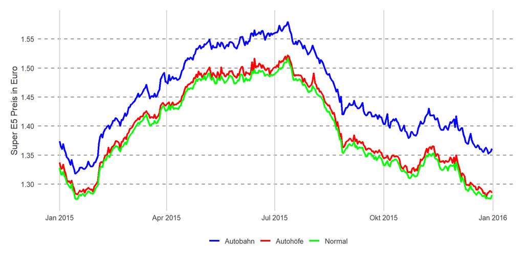

```r
  # collect data
  price_e5_street <- autobahn_price %>%
    select(day, e5) %>%
    rename(autobahn = e5) %>%
    mutate(autohof = autohof_price$e5,
           normal = normal_price$e5)

  # plot prices by street type
  ggplot(price_e5_street, aes(x = day)) +
    geom_line(aes(y = autobahn, colour = "Autobahn"),
              size = 1.2) +
    geom_line(aes(y = autohof, colour = "Autohöfe"),
              size = 1.2) +
    geom_line(aes(y = normal, colour = "Normal"),
              size = 1.2) +
    theme_base() +
    theme(panel.grid.major.y = element_line(linetype = 2, colour = "grey55")) +
    labs(x = NULL, y = "Super E5 Preis in Euro") +
    scale_y_continuous(expand = expansion(add = 0.02),
                       n.breaks = 8) +
    scale_colour_manual("",
                        values = c("Autobahn" = "blue", "Autohöfe" = "red",
                                   "Normal" = "green"))
```

### nach Regionen: Nord / Ost / Süd / West

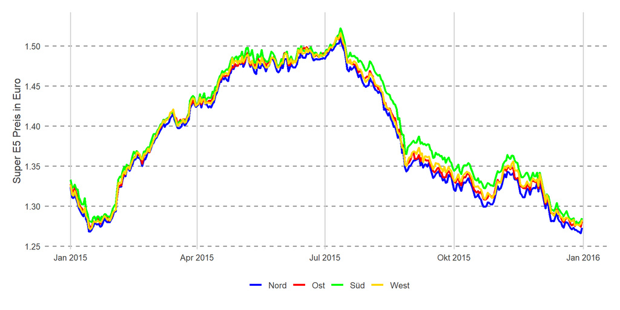

```r
  # collect data
  price_e5_regions<- north_price %>%
    select(day, e5) %>%
    rename(north = e5) %>%
    mutate(east = east_price$e5,
           south = south_price$e5,
           west = west_price$e5)

  # plot data by regions
  ggplot(price_e5_regions, aes(x = day)) +
    geom_line(aes(y = north, colour = "Nord"),
              size = 1.2) +
    geom_line(aes(y = east, colour = "Ost"),
              size = 1.2) +
    geom_line(aes(y = south, colour = "Süd"),
              size = 1.2) +
    geom_line(aes(y = west, colour = "West"),
              size = 1.2) +
    theme_base() +
    theme(panel.grid.major.y = element_line(linetype = 2, colour = "grey55")) +
    labs(x = NULL, y = "Super E5 Preis in Euro") +
    scale_y_continuous(expand = expansion(add = 0.02),
                       n.breaks = 8) +
    scale_colour_manual("",
                        values = c("Nord" = "blue", "Ost" = "red",
                                   "Süd" = "green", "West" = "gold"))
```

### nach Siedlungsdichte: Stadt vs. Land

Die Zuordnung der Tankstellen zu städtisch oder ländlich geprägten Landkreisen erfolgt auf Basis der im Datensatz enthaltenen Angaben zu Längen- und Breitengrad der einzelnen Tankstellen. Die Einteilung der Landkreise beruht auf Daten des Bundesinstituts für Bau-, Stadt- und Raumforschung (BBSR).

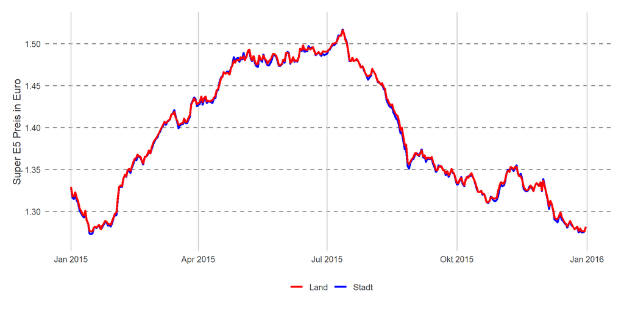

```r
  # collect data
  price_e5_citrur<- city_price %>%
    select(day, e5) %>%
    rename(city = e5) %>%
    mutate(rural = rural_price$e5)

  # plot prices city vs. rural
  ggplot(price_e5_citrur, aes(x = day)) +
    geom_line(aes(y = city, colour = "Stadt"),
              size = 1.2) +
    geom_line(aes(y = rural, colour = "Land"),
              size = 1.2) +
    theme_base() +
    theme(panel.grid.major.y = element_line(linetype = 2, colour = "grey55")) +
    labs(x = NULL, y = "Super E5 Preis in Euro") +
    scale_y_continuous(expand = expansion(add = 0.02),
                       n.breaks = 8) +
    scale_colour_manual("",
                        values = c("Stadt" = "blue", "Land" = "red"))
```

### nach Marken

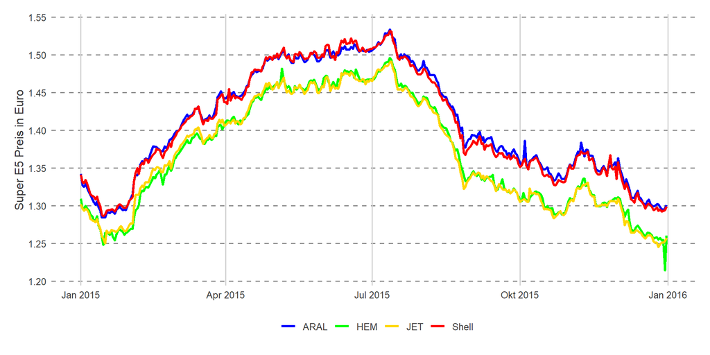

```r
  # collect data
  price_e5_brand <- aral_price %>%
    select(day, e5) %>%
    rename(aral = e5) %>%
    mutate(shell = shell_price$e5,
           hem = hem_price$e5,
           jet = jet_price$e5)

  # plot prices by selected brands
  ggplot(price_e5_brand, aes(x = day)) +
    geom_line(aes(y = aral, colour = "ARAL"),
              size = 1.2) +
    geom_line(aes(y = shell, colour = "Shell"),
              size = 1.2) +
    geom_line(aes(y = hem, colour = "HEM"),
              size = 1.2) +
    geom_line(aes(y = jet, colour = "JET"),
              size = 1.2) +
    theme_base() +
    theme(panel.grid.major.y = element_line(linetype = 2, colour = "grey55")) +
    labs(x = NULL, y = "Super E5 Preis in Euro") +
    scale_y_continuous(expand = expansion(add = 0.02),
                       n.breaks = 8) +
    scale_colour_manual("",
                        values = c("ARAL" = "blue", "Shell" = "red",
                                   "HEM" = "green", "JET" = "gold"))
```

## Preiszyklen: Super E5

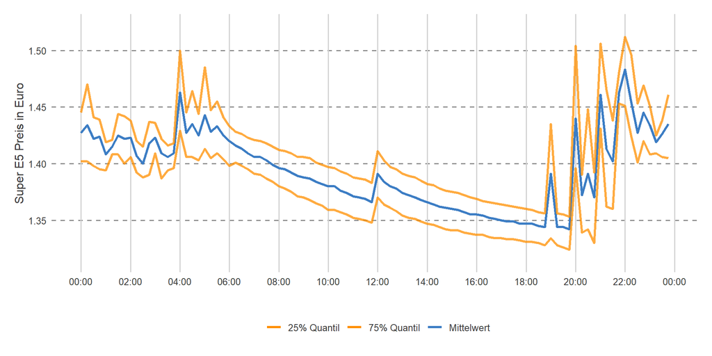

```r
  # query average prices per 15 minutes
  query_price_minute <- paste0("
                    SELECT
                      EXTRACT(HOUR FROM dbtime) AS hour,
                        EXTRACT(MINUTE FROM dbtime) AS minute,
                        round(avg(pe5_avg)::numeric, 3) AS avg,
                        round(avg(pe5_median)::numeric, 3) AS median,
                        round(avg(pe5_p025)::numeric, 3) AS p025,
                        round(avg(pe5_p075)::numeric, 3) AS p075
                    FROM (
                        SELECT
                          time_bucket_gapfill('15 minute', time) AS dbtime,
                          locf(round(avg(pe5), 3)) AS pe5_avg,
                          percentile_cont(0.5) within group (order by pe5) AS pe5_median,
                          percentile_cont(0.25) within group (order by pe5) AS pe5_p025,
                          percentile_cont(0.75) within group (order by pe5) AS pe5_p075
                      FROM
                        price
                      WHERE
                        (time BETWEEN '", year, "-01-01 00:00:01'
                              AND '", year, "-12-31 23:59:59')
                      AND
                        (pe5 IS NOT NULL)
                      GROUP BY
                        dbtime
                      ORDER BY
                        dbtime ASC) price15min
                    GROUP BY
                      HOUR,
                      MINUTE
                    ORDER BY
                      HOUR,
                      MINUTE;")

  price_minute <- dbGetQuery(dbcon, query_price_minute) %>%
    as_tibble() %>%
    # replace extracted HH:mm by datetime
    mutate(time = seq(ISOdatetime(year,1,1,0,0,0), by = "15 min", length.out = 96)) %>%
    select(-c(hour, minute))

  # plot average prices 15 min interval
  ggplot(price_minute, aes(x = time)) +
    geom_line(aes(y = avg, colour = "Mittelwert"),
              size = 1.2) +
    geom_line(aes(y = p025, colour = "25% Quantil"),
              size = 1.2,
              alpha = 0.75) +
    geom_line(aes(y = p075, colour = "75% Quantil"),
              size = 1.2,
              alpha = 0.75) +
    theme_base() +
    theme(panel.grid.major.y = element_line(linetype = 2, colour = "grey55")) +
    labs(x = NULL, y = "Super E5 Preis in Euro") +
    scale_y_continuous(expand = expansion(add = 0.02),
                       n.breaks = 8) +
    scale_x_datetime("",
                     date_breaks = "2 hours",
                     date_labels = "%H:%M") +
    scale_colour_manual("",
                        values = c("Mittelwert" = colors[3], "25% Quantil" = colors[1], "75% Quantil" = colors[1]))
```

### Stadt / Land / Autobahn

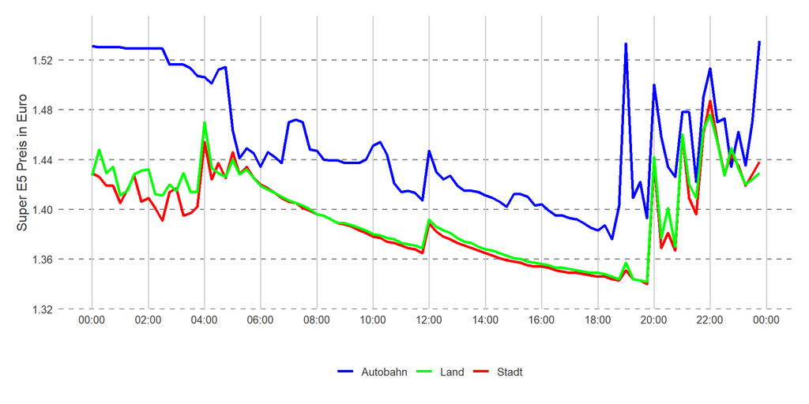

```r
  # autobahn price cycle
  query_price_minute_autobahn <- paste0("
                    SELECT
                        EXTRACT(HOUR FROM dbtime) AS hour,
                        EXTRACT(MINUTE FROM dbtime) AS minute,
                        round(avg(pe5_avg)::numeric, 3) AS avg
                    FROM (
                        SELECT
                            time_bucket_gapfill('15 minute', time) AS dbtime,
                            locf(round(avg(pe5), 3)) AS pe5_avg
                        FROM
                          price
                        WHERE
                          (stid = ANY('{",stations_cat_ids$autobahn , "}'))
                      AND
                            (time BETWEEN '", year, "-01-01 00:00:01'
                                  AND '", year, "-12-31 23:59:59')
                          AND
                            (pe5 IS NOT NULL)
                        GROUP BY
                          dbtime
                        ORDER BY
                          dbtime) price15min
                    GROUP BY
                      HOUR,
                      MINUTE
                    ORDER BY
                      HOUR,
                      MINUTE;")

  price_minute_autobahn <- dbGetQuery(dbcon, query_price_minute_autobahn) %>%
    as_tibble() %>%
    # replace extracted HH:mm by datetime
    mutate(time = seq(ISOdatetime(year,1,1,0,0,0), by = "15 min", length.out = 96)) %>%
    select(-c(hour, minute)) %>%
    rename(autobahn = avg)

  # city price cycle
  query_price_minute_city <- paste0("
                    SELECT
                        EXTRACT(HOUR FROM dbtime) AS hour,
                        EXTRACT(MINUTE FROM dbtime) AS minute,
                        round(avg(pe5_avg)::numeric, 3) AS avg
                    FROM (
                        SELECT
                            time_bucket_gapfill('15 minute', time) AS dbtime,
                            locf(round(avg(pe5), 3)) AS pe5_avg
                        FROM
                          price
                        WHERE
                          (stid = ANY('{",stations_cat_ids$city , "}'))
                      AND
                              (time BETWEEN '", year, "-01-01 00:00:01'
                                    AND '", year, "-12-31 23:59:59')
                            AND
                              (pe5 IS NOT NULL)
                        GROUP BY
                          dbtime
                        ORDER BY
                          dbtime) price15min
                    GROUP BY
                      HOUR,
                      MINUTE
                    ORDER BY
                      HOUR,
                      MINUTE;")

  price_minute_city <- dbGetQuery(dbcon, query_price_minute_city) %>%
    as_tibble() %>%
    # replace extracted HH:mm by datetime
    mutate(time = seq(ISOdatetime(year,1,1,0,0,0), by = "15 min", length.out = 96)) %>%
    select(-c(hour, minute)) %>%
    rename(city = avg)

  # rural price cycle
  query_price_minute_rural <- paste0("
                    SELECT
                        EXTRACT(HOUR FROM dbtime) AS hour,
                        EXTRACT(MINUTE FROM dbtime) AS minute,
                        round(avg(pe5_avg)::numeric, 3) AS avg
                    FROM (
                        SELECT
                            time_bucket_gapfill('15 minute', time) AS dbtime,
                            locf(round(avg(pe5), 3)) AS pe5_avg
                        FROM
                          price
                        WHERE
                          (stid = ANY('{",stations_cat_ids$rural , "}'))
                      AND
                            (time BETWEEN '", year, "-01-01 00:00:01'
                                  AND '", year, "-12-31 23:59:59')
                        AND
                              (pe5 IS NOT NULL)
                        GROUP BY
                          dbtime
                        ORDER BY
                          dbtime) price15min
                    GROUP BY
                      HOUR,
                      MINUTE
                    ORDER BY
                      HOUR,
                      MINUTE;")

  price_minute_rural <- dbGetQuery(dbcon, query_price_minute_rural) %>%
    as_tibble() %>%
    # replace extracted HH:mm by datetime
    mutate(time = seq(ISOdatetime(year,1,1,0,0,0), by = "15 min", length.out = 96)) %>%
    select(-c(hour, minute)) %>%
    rename(rural = avg)

  # join data
  price_minute_street <- price_minute_autobahn %>%
    left_join(price_minute_city, by = "time") %>%
    left_join(price_minute_rural, by = "time")

  # plot price cycles autobahn / city / rural
  ggplot(price_minute_street, aes(x = time)) +
    geom_line(aes(y = autobahn, colour = "Autobahn"),
              size = 1.2) +
    geom_line(aes(y = city, colour = "Stadt"),
              size = 1.2) +
    geom_line(aes(y = rural, colour = "Land"),
              size = 1.2) +
    theme_base() +
    theme(panel.grid.major.y = element_line(linetype = 2, colour = "grey55")) +
    labs(x = NULL, y = "Super E5 Preis in Euro") +
    scale_y_continuous(expand = expansion(add = 0.02),
                       n.breaks = 8) +
    scale_x_datetime("",
                     date_breaks = "2 hours",
                     date_labels = "%H:%M") +
    scale_colour_manual("",
                        values = c("Autobahn" = "blue", "Stadt" = "red", "Land" = "green"))
```

### nach Regionen: Nord / Ost / Süd / West

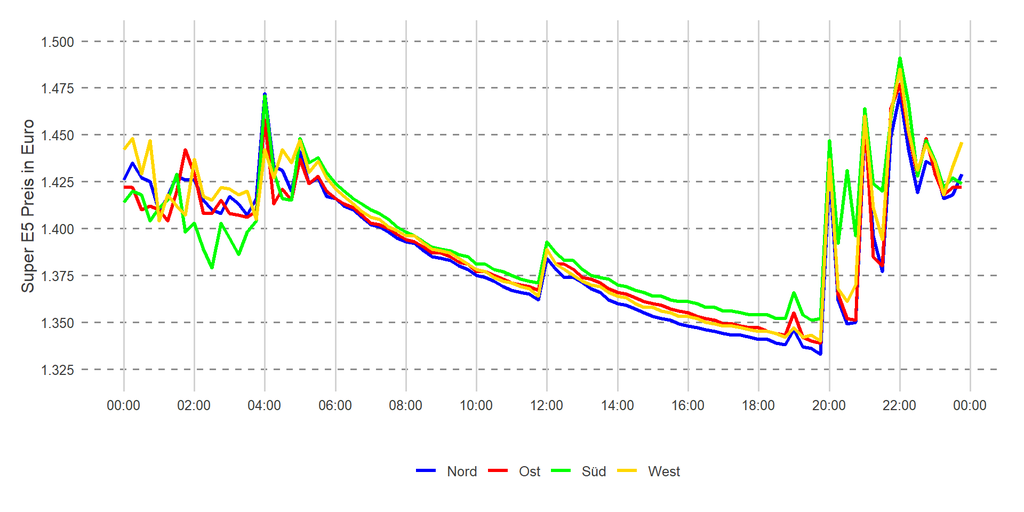

```r
  # north price cycle
  query_price_minute_north <- paste0("
                    SELECT
                        EXTRACT(HOUR FROM dbtime) AS hour,
                        EXTRACT(MINUTE FROM dbtime) AS minute,
                        round(avg(pe5_avg)::numeric, 3) AS avg
                    FROM (
                        SELECT
                            time_bucket_gapfill('15 minute', time) AS dbtime,
                            locf(round(avg(pe5), 3)) AS pe5_avg
                        FROM
                          price
                        WHERE
                          (stid = ANY('{",stations_cat_ids$north , "}'))
                      AND
                              (time BETWEEN '", year, "-01-01 00:00:01'
                                    AND '", year, "-12-31 23:59:59')
                            AND
                              (pe5 IS NOT NULL)
                        GROUP BY
                        dbtime
                        ORDER BY
                          dbtime) price15min
                    GROUP BY
                      HOUR,
                      MINUTE
                    ORDER BY
                      HOUR,
                      MINUTE;")

  price_minute_north <- dbGetQuery(dbcon, query_price_minute_north) %>%
    as_tibble() %>%
    # replace extracted HH:mm by datetime
    mutate(time = seq(ISOdatetime(year,1,1,0,0,0), by = "15 min", length.out = 96)) %>%
    select(-c(hour, minute)) %>%
    rename(north = avg)

  # east price cycle
  query_price_minute_east <- paste0("
                    SELECT
                        EXTRACT(HOUR FROM dbtime) AS hour,
                        EXTRACT(MINUTE FROM dbtime) AS minute,
                        round(avg(pe5_avg)::numeric, 3) AS avg
                    FROM (
                        SELECT
                            time_bucket_gapfill('15 minute', time) AS dbtime,
                            locf(round(avg(pe5), 3)) AS pe5_avg
                        FROM
                          price
                        WHERE
                          (stid = ANY('{",stations_cat_ids$east , "}'))
                      AND
                              (time BETWEEN '", year, "-01-01 00:00:01'
                                  AND '", year, "-12-31 23:59:59')
                          AND
                              (pe5 IS NOT NULL)
                        GROUP BY
                          dbtime
                        ORDER BY
                          dbtime) price15min
                    GROUP BY
                      HOUR,
                      MINUTE
                    ORDER BY
                      HOUR,
                      MINUTE;")

  price_minute_east <- dbGetQuery(dbcon, query_price_minute_east) %>%
    as_tibble() %>%
    # replace extracted HH:mm by datetime
    mutate(time = seq(ISOdatetime(year,1,1,0,0,0), by = "15 min", length.out = 96)) %>%
    select(-c(hour, minute)) %>%
    rename(east = avg)

  # south price cycle
  query_price_minute_south <- paste0("
                    SELECT
                        EXTRACT(HOUR FROM dbtime) AS hour,
                        EXTRACT(MINUTE FROM dbtime) AS minute,
                        round(avg(pe5_avg)::numeric, 3) AS avg
                    FROM (
                        SELECT
                            time_bucket_gapfill('15 minute', time) AS dbtime,
                            locf(round(avg(pe5), 3)) AS pe5_avg
                        FROM
                          price
                        WHERE
                          (stid = ANY('{",stations_cat_ids$south , "}'))
                      AND
                          (time BETWEEN '", year, "-01-01 00:00:01'
                                AND '", year, "-12-31 23:59:59')
                        AND
                              (pe5 IS NOT NULL)
                        GROUP BY
                        dbtime
                        ORDER BY
                          dbtime) price15min
                    GROUP BY
                      HOUR,
                      MINUTE
                    ORDER BY
                      HOUR,
                      MINUTE;")

  price_minute_south <- dbGetQuery(dbcon, query_price_minute_south) %>%
    as_tibble() %>%
    # replace extracted HH:mm by datetime
    mutate(time = seq(ISOdatetime(year,1,1,0,0,0), by = "15 min", length.out = 96)) %>%
    select(-c(hour, minute)) %>%
    rename(south = avg)

  # west price cycle
  query_price_minute_west <- paste0("
                    SELECT
                        EXTRACT(HOUR FROM dbtime) AS hour,
                        EXTRACT(MINUTE FROM dbtime) AS minute,
                        round(avg(pe5_avg)::numeric, 3) AS avg
                    FROM (
                        SELECT
                            time_bucket_gapfill('15 minute', time) AS dbtime,
                            locf(round(avg(pe5), 3)) AS pe5_avg
                        FROM
                        price
                        WHERE
                          (stid = ANY('{",stations_cat_ids$west , "}'))
                      AND
                              (time BETWEEN '", year, "-01-01 00:00:01'
                                    AND '", year, "-12-31 23:59:59')
                          AND
                              (pe5 IS NOT NULL)
                        GROUP BY
                          dbtime
                        ORDER BY
                          dbtime) price15min
                    GROUP BY
                      HOUR,
                      MINUTE
                    ORDER BY
                      HOUR,
                      MINUTE;")

  price_minute_west <- dbGetQuery(dbcon, query_price_minute_west) %>%
    as_tibble() %>%
    # replace extracted HH:mm by datetime
    mutate(time = seq(ISOdatetime(year,1,1,0,0,0), by = "15 min", length.out = 96)) %>%
    select(-c(hour, minute)) %>%
    rename(west = avg)

  # join data
  price_minute_region <- price_minute_north %>%
    left_join(price_minute_east, by = "time") %>%
    left_join(price_minute_south, by = "time") %>%
    left_join(price_minute_west, by = "time")

  # plot region price cycles
  ggplot(price_minute_region, aes(x = time)) +
    geom_line(aes(y = north, colour = "Nord"),
              size = 1.2) +
    geom_line(aes(y = east, colour = "Ost"),
              size = 1.2) +
    geom_line(aes(y = south, colour = "Süd"),
              size = 1.2) +
    geom_line(aes(y = west, colour = "West"),
              size = 1.2) +
    theme_base() +
    theme(panel.grid.major.y = element_line(linetype = 2, colour = "grey55")) +
    labs(x = NULL, y = "Super E5 Preis in Euro") +
    scale_y_continuous(expand = expansion(add = 0.02),
                       n.breaks = 8) +
    scale_x_datetime("",
                     date_breaks = "2 hours",
                     date_labels = "%H:%M") +
    scale_colour_manual("",
                        values = c("Nord" = "blue", "Ost" = "red",
                                   "Süd" = "green", "West" = "gold"))
```

### nach Marken

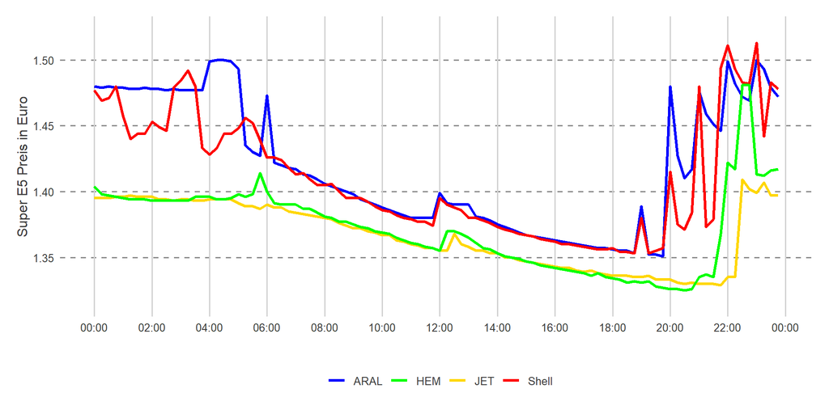

```r
  # aral price cycle
  query_price_minute_aral <- paste0("
                    SELECT
                        EXTRACT(HOUR FROM dbtime) AS hour,
                        EXTRACT(MINUTE FROM dbtime) AS minute,
                        round(avg(pe5_avg)::numeric, 3) AS avg
                    FROM (
                        SELECT
                            time_bucket_gapfill('15 minute', time) AS dbtime,
                            locf(round(avg(pe5), 3)) AS pe5_avg
                        FROM
                          price
                        WHERE
                          (stid = ANY('{",stations_cat_ids$aral , "}'))
                        AND
                          (time BETWEEN '", year, "-01-01 00:00:01'
                                AND '", year, "-12-31 23:59:59')
                        AND
                          (pe5 IS NOT NULL)
                        GROUP BY
                          dbtime
                        ORDER BY
                          dbtime) price15min
                    GROUP BY
                      HOUR,
                      MINUTE
                    ORDER BY
                      HOUR,
                      MINUTE;")

  price_minute_aral <- dbGetQuery(dbcon, query_price_minute_aral) %>%
    as_tibble() %>%
    # replace extracted HH:mm by datetime
    mutate(time = seq(ISOdatetime(year,1,1,0,0,0), by = "15 min", length.out = 96)) %>%
    select(-c(hour, minute)) %>%
    rename(aral = avg)

  # shell price cycle
  query_price_minute_shell <- paste0("
                    SELECT
                        EXTRACT(HOUR FROM dbtime) AS hour,
                        EXTRACT(MINUTE FROM dbtime) AS minute,
                        round(avg(pe5_avg)::numeric, 3) AS avg
                    FROM (
                        SELECT
                            time_bucket_gapfill('15 minute', time) AS dbtime,
                            locf(round(avg(pe5), 3)) AS pe5_avg
                        FROM
                          price
                        WHERE
                          (stid = ANY('{",stations_cat_ids$shell , "}'))
                        AND
                          (time BETWEEN '", year, "-01-01 00:00:01'
                                AND '", year, "-12-31 23:59:59')
                        AND
                          (pe5 IS NOT NULL)
                        GROUP BY
                          dbtime
                        ORDER BY
                          dbtime) price15min
                    GROUP BY
                      HOUR,
                      MINUTE
                    ORDER BY
                      HOUR,
                      MINUTE;")

  price_minute_shell <- dbGetQuery(dbcon, query_price_minute_shell) %>%
    as_tibble() %>%
    # replace extracted HH:mm by datetime
    mutate(time = seq(ISOdatetime(year,1,1,0,0,0), by = "15 min", length.out = 96)) %>%
    select(-c(hour, minute)) %>%
    rename(shell = avg)

  # jet price cycle
  query_price_minute_jet <- paste0("
                    SELECT
                        EXTRACT(HOUR FROM dbtime) AS hour,
                        EXTRACT(MINUTE FROM dbtime) AS minute,
                        round(avg(pe5_avg)::numeric, 3) AS avg
                    FROM (
                        SELECT
                            time_bucket_gapfill('15 minute', time) AS dbtime,
                            locf(round(avg(pe5), 3)) AS pe5_avg
                        FROM
                          price
                        WHERE
                          (stid = ANY('{",stations_cat_ids$jet , "}'))
                        AND
                          (time BETWEEN '", year, "-01-01 00:00:01'
                                AND '", year, "-12-31 23:59:59')
                        AND
                          (pe5 IS NOT NULL)
                        GROUP BY
                          dbtime
                        ORDER BY
                          dbtime) price15min
                    GROUP BY
                      HOUR,
                      MINUTE
                    ORDER BY
                      HOUR,
                      MINUTE;")

  price_minute_jet <- dbGetQuery(dbcon, query_price_minute_jet) %>%
    as_tibble() %>%
    # replace extracted HH:mm by datetime
    mutate(time = seq(ISOdatetime(year,1,1,0,0,0), by = "15 min", length.out = 96)) %>%
    select(-c(hour, minute)) %>%
    rename(jet = avg)

  # hem price cycle
  query_price_minute_hem <- paste0("
                    SELECT
                        EXTRACT(HOUR FROM dbtime) AS hour,
                        EXTRACT(MINUTE FROM dbtime) AS minute,
                        round(avg(pe5_avg)::numeric, 3) AS avg
                    FROM (
                        SELECT
                            time_bucket_gapfill('15 minute', time) AS dbtime,
                            locf(round(avg(pe5), 3)) AS pe5_avg
                        FROM
                          price
                        WHERE
                          (stid = ANY('{",stations_cat_ids$hem , "}'))
                        AND
                          (time BETWEEN '", year, "-01-01 00:00:01'
                                AND '", year, "-12-31 23:59:59')
                        AND
                          (pe5 IS NOT NULL)
                        GROUP BY
                          dbtime
                        ORDER BY
                          dbtime) price15min
                    GROUP BY
                      HOUR,
                      MINUTE
                    ORDER BY
                      HOUR,
                      MINUTE;")

  price_minute_hem <- dbGetQuery(dbcon, query_price_minute_hem) %>%
    as_tibble() %>%
    # replace extracted HH:mm by datetime
    mutate(time = seq(ISOdatetime(year,1,1,0,0,0), by = "15 min", length.out = 96)) %>%
    select(-c(hour, minute)) %>%
    rename(hem = avg)

  # join data
  price_minute_brands <- price_minute_aral %>%
    left_join(price_minute_shell, by = "time") %>%
    left_join(price_minute_jet, by = "time") %>%
    left_join(price_minute_hem, by = "time")


  # plot price cycles brands
  ggplot(price_minute_brands, aes(x = time)) +
    geom_line(aes(y = aral, colour = "ARAL"),
              size = 1.2) +
    geom_line(aes(y = shell, colour = "Shell"),
              size = 1.2) +
    geom_line(aes(y = jet, colour = "JET"),
              size = 1.2) +
    geom_line(aes(y = hem, colour = "HEM"),
              size = 1.2) +
    theme_base() +
    theme(panel.grid.major.y = element_line(linetype = 2, colour = "grey55")) +
    labs(x = NULL, y = "Super E5 Preis in Euro") +
    scale_y_continuous(expand = expansion(add = 0.02),
                       n.breaks = 8) +
    scale_x_datetime("",
                     date_breaks = "2 hours",
                     date_labels = "%H:%M") +
    scale_colour_manual("",
                        values = c("ARAL" = "blue", "Shell" = "red",
                                   "HEM" = "green", "JET" = "gold"),
                        guide = guide_legend(nrow = 1))
```

### nach Monaten

Aufgrund der unterschiedlichen Preisniveaus in den einzelnen Monaten wurden die folgenden Daten zu Preiszyklen für eine bessere Vergleichbarkeit um den jeweiligen monatlichen Mittelwert bereinigt.

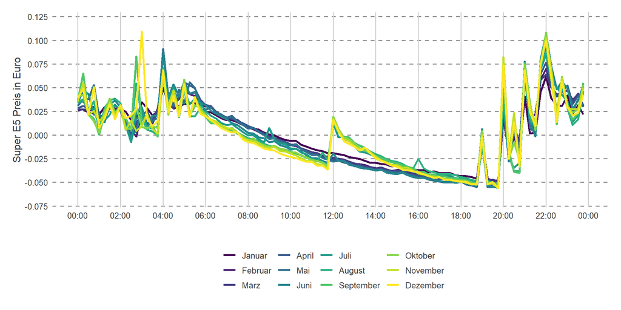

```r
  # query price cycles by month
  query_price_minute_month <- paste0("
                    SELECT
                      EXTRACT(MONTH FROM dbtime) AS month,
                        EXTRACT(HOUR FROM dbtime) AS hour,
                        EXTRACT(MINUTE FROM dbtime) AS minute,
                        round(avg(pe5_avg)::numeric, 3) AS avg
                    FROM (
                        SELECT
                          time_bucket_gapfill('15 minute', time) AS dbtime,
                          locf(round(avg(pe5), 3)) AS pe5_avg
                      FROM
                        price
                      WHERE
                        (time BETWEEN '", year, "-01-01 00:00:01'
                              AND '", year, "-12-31 23:59:59')
                      AND
                           (pe5 IS NOT NULL)
                      GROUP BY
                        dbtime
                      ORDER BY
                        dbtime ASC) price15min
                    GROUP BY
                      MONTH,
                      HOUR,
                      MINUTE
                    ORDER BY
                      MONTH,
                      HOUR,
                      MINUTE;")

  price_minute_month <- dbGetQuery(dbcon, query_price_minute_month) %>%
    as_tibble() %>%
    # replace extracted HH:mm by datetime
    mutate(time = rep(seq(ISOdatetime(year,1,1,0,0,0), by = "15 min", length.out = 96), 12)) %>%
    select(-c(hour, minute)) %>%
    group_by(month) %>%
    mutate(avg = avg - mean(avg))

  # plot price cycles by month
  ggplot(price_minute_month, aes(x = time)) +
    geom_line(aes(y = avg, colour = as.factor(month)),
              size = 1.2) +
    theme_base() +
    theme(panel.grid.major.y = element_line(linetype = 2, colour = "grey55")) +
    labs(x = NULL, y = "Super E5 Preis in Euro") +
    scale_y_continuous(expand = expansion(add = 0.02),
                       n.breaks = 8) +
    scale_x_datetime("",
                     date_breaks = "2 hours",
                     date_labels = "%H:%M") +
    scale_colour_viridis_d(name = "",
                           labels = format(seq(ISOdate(2000,1,1), by = "month", length.out = 12), "%B"))
```

### nach Monaten und Wochentagen

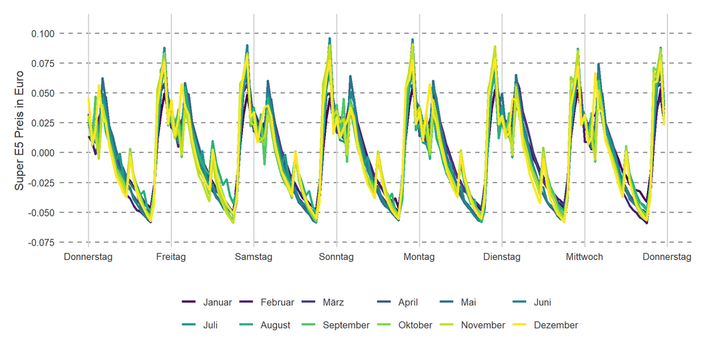

```r
  # query price cycles by day of the week and month
  query_price_minute_monthday <- paste0("
                    SELECT
                      EXTRACT(MONTH FROM dbtime) AS month,
                        EXTRACT(ISODOW FROM dbtime) AS day,
                        EXTRACT(HOUR FROM dbtime) AS hour,
                        round(avg(pe5_avg)::numeric, 3) AS avg
                    FROM (
                        SELECT
                          time_bucket_gapfill('1 hour', time) AS dbtime,
                          locf(round(avg(pe5), 3)) AS pe5_avg
                      FROM price
                      WHERE (time BETWEEN '", year, "-01-01 00:00:01' AND '", year, "-12-31 23:59:59') AND
                                (pe5 IS NOT NULL)
                      GROUP BY dbtime
                      ORDER BY dbtime ASC) price1day
                    GROUP BY MONTH, DAY, HOUR
                    ORDER BY MONTH, DAY, HOUR;")

  price_minute_monthday_db <- dbGetQuery(dbcon, query_price_minute_monthday) %>%
    as_tibble()

  price_minute_monthday <- price_minute_monthday_db %>%
    # replace extracted dd:hh by datetime
    mutate(time = rep(seq(ISOdatetime(year,1,1,0,0,0), by = "1 hour", length.out = 24*7), 12)) %>%
    select(-c(day, hour)) %>%
    # remove monthly mean
    group_by(month) %>%
    mutate(avg = avg - mean(avg))

  # plot price cycle day of the week
  ggplot(price_minute_monthday, aes(x = time)) +
    geom_line(aes(y = avg, colour = as.factor(month)),
              size = 1.2) +
    theme_base() +
    theme(panel.grid.major.y = element_line(linetype = 2, colour = "grey55")) +
    labs(x = NULL, y = "Super E5 Preis in Euro") +
    scale_y_continuous(expand = expansion(add = 0.02),
                       n.breaks = 8) +
    scale_x_datetime("",
                     date_breaks = "1 day",
                     date_labels = "%A") +
    scale_colour_viridis_d(name = "",
                           labels = format(seq(ISOdate(2000,1,1), by = "month", length.out = 12), "%B"),
                           guide = guide_legend(nrow = 2, byrow = T))
```

## Datenquellen

- Tankstellen- und Preisinformationen: [Tankerkönig](https://creativecommons.tankerkoenig.de/) Kartendaten: [© GeoBasis-DE / BKG (2019)](https://gdz.bkg.bund.de/index.php/default/digitale-geodaten/verwaltungsgebiete.html?___store=default)
- Gebietsfläche Bundesländer und Landkreise: Statistisches Bundesamt (Destatis). [Genesis-Tabelle 11111-0001 und 11111-0002](https://www-genesis.destatis.de/genesis/online?operation=statistic&levelindex=0&levelid=1590163091153&code=11111)
- Einwohner Bundesländer und Landkreise: Statistisches Bundesamt (Destatis). [Genesis-Tabelle 12411-0010 und 12411-0015](https://www-genesis.destatis.de/genesis/online?operation=statistic&levelindex=0&levelid=1590163091153&code=12411)
- Zugelassene PKW Landkreise: Statistisches Bundesamt (Destatis). [Genesis-Tabelle 46251-0006](https://www-genesis.destatis.de/genesis/online?operation=statistic&levelindex=0&levelid=1590163236361&code=46251)
- Landkreistypen: Bundesinstitut für Bau-, Stadt- und Raumforschung [Referenz Kreise/Kreisregionen zu Kreistypen, Gebietsstand 31.12.2017](https://www.bbsr.bund.de/BBSR/DE/Raumbeobachtung/Raumabgrenzungen/deutschland/kreise/Kreistypen4/download-ref-kreistypen-xls.html)
- Rohölpreise (Brent): [Finanzen.net](https://www.finanzen.net/rohstoffe/oelpreis/historisch)